# Rhizosphere metabolome project - analysis of plant data

Benjamin Delory

31/08/2020

This document details the R pipeline used to explore and analyse the data presented in **Delory et al (2020) The rhizosphere metabolome triggers species-specific and context-dependent root responses in later arriving plants**.

# Load R packages

```r
library(ggplot2)
library(gridExtra)
library(ggpubr)
library(smatr)
library(FactoMineR)
library(piecewiseSEM)
```

# Create R functions for data analysis

## `bootstrap_mean`

`bootstrap_mean` is an R function calculating treatment means, compatibility intervals (bootstrap resampling using the percentile method), and effect sizes for one response variable. The number of bootstrap resamples is set using `n_perm` (default to 10000).

This function is a modified version of the [function coded by Masahiro Ryo](https://github.com/masahiroryo/joint-ES-estimate/blob/master/20190801_analysis_v2.0.R) for the following paper: [Rillig et al (2019). The role of multiple global change factors in driving soil functions and microbial biodiversity. Science, 366, 886-890](https://science.sciencemag.org/content/366/6467/886).

```r
bootstrap_mean <- function(response, data=data, n_perm = 10000){

  summary <- data.frame(Species=NA, Treatment=NA, lowCI=NA, mean=NA, highCI=NA)
  species <- sort(unique(data$Species))
  treatments <- sort(unique(data$Treatment))
  row<-0

  for (sp in species){

    for (treat in treatments){

      bs <- numeric(0)
      population <- na.omit(data[data$Treatment==treat & data$Species==sp, response])
      size <- length(population)

      if (size!=0){

        row<-row+1

        set.seed(1) #For reproducibility

        for (i in c(1:n_perm)){

          k <- mean(sample(population, size, replace = T))
          bs <- append(bs, k)}

        summary[row,1:2] <- c(sp, treat)
        summary[row,3:5] <- c(quantile(bs, .025), mean(population), quantile(bs, .975))}}}

  summary$ES<-NA
  summary$ES[summary$Species=="Dianthus deltoides"]<-100*(summary$mean[summary$Species=="Dianthus deltoides"]-summary$mean[summary$Species=="Dianthus deltoides" & summary$Treatment=="Soil"])/summary$mean[summary$Species=="Dianthus deltoides" & summary$Treatment=="Soil"]
  summary$ES[summary$Species=="Festuca rubra"]<-100*(summary$mean[summary$Species=="Festuca rubra"]-summary$mean[summary$Species=="Festuca rubra" & summary$Treatment=="Soil"])/summary$mean[summary$Species=="Festuca rubra" & summary$Treatment=="Soil"]

  return(summary)}
```

## `bootstrap_ES`

`bootstrap_ES` is an R function calculating unstandardised effect sizes for each treatment and their compatibility intervals (bootstrap resampling using the percentile method) for one response variable. The number of bootstrap resamples is set using `n_perm` (default to 10000). The argument `plot` can be used to create a histogram displaying the results.

This function is a modified version of the [function coded by Masahiro Ryo](https://github.com/masahiroryo/joint-ES-estimate/blob/master/20190801_analysis_v2.0.R) for the following paper: [Rillig et al (2019). The role of multiple global change factors in driving soil functions and microbial biodiversity. Science, 366, 886-890](https://science.sciencemag.org/content/366/6467/886).

```r
bootstrap_ES <- function(response, data=data, n_perm = 10000, plot=TRUE){

  summary <- data.frame(Species=NA, Contrast=NA, lowCI=NA, ES=NA, highCI=NA)
  alles <- data.frame()
  species <- sort(unique(data$Species))
  treatments <- sort(unique(data$Treatment))
  comb<-combn(treatments, 2)
  row<-0

  for (sp in species){

    for (col in 1:ncol(comb)){

      bs <- numeric(0)
      population_1 <- na.omit(data[data$Treatment==comb[1,col] & data$Species==sp, response])
      population_2 <- na.omit(data[data$Treatment==comb[2,col] & data$Species==sp, response])
      size_1 <- length(population_1)
      size_2 <- length(population_2)

      if (size_1==0|size_2==0){} else {

        row<-row+1

        set.seed(1) #For reproducibility

        for (i in c(1:n_perm)){

          k_1 <- mean(sample(population_1, size_1, replace = T))
          k_2 <- mean(sample(population_2, size_2, replace = T))
          bs <- append(bs, k_1-k_2)}

      summary[row,1:2] <- c(sp, paste(comb[1,col], "-", comb[2,col], sep=""))
      summary[row,3:5] <- c(quantile(bs, .025), mean(population_1)-mean(population_2), quantile(bs, .975))
      alles<-rbind(alles, data.frame(Species=rep(sp, n_perm), Contrast=rep(paste(comb[1,col], "-", comb[2,col], sep=""), n_perm), ES=bs))}

      if (plot==TRUE){
        hist(bs, main=paste(sp, " : ", comb[1,col], "-", comb[2,col], sep=""),
             xlab=paste("ES", response, sep=" "))
        points(mean(population_1)-mean(population_2), 0, pch=16, cex=2, col="red")
        segments(x0=quantile(bs, .025), y0=0, x1=quantile(bs, .975), y1=0, lwd=2, col="red")}}}

  return(list(summary=summary, bootstrap=alles))}
```

# Load data in R

```r
data<-read.csv("C:/Users/Delory/Documents/GitHub/rhizometabolome/data/Data_plants.csv", header=TRUE)
data<-as.data.frame(data)
data$Species<-factor(data$Species)
levels(data$Species)<-c("Dianthus deltoides", "Festuca rubra")
```

# Unit conversion

```r
data$LDMC<-data$LDMC*10 #Express leaf dry matter content in mg/g
data$Nleaf<-data$Nleaf*10 #Express leaf nitrogen content in mg/g
data$Cleaf<-data$Cleaf*10 #Express leaf carbon content in mg/g
data$Nroot<-data$Nroot*10 #Express root nitrogen content in mg/g
data$Croot<-data$Croot*10 #Express root carbon content in mg/g
data$Nshoot<-data$Nshoot*10 #Express shoot nitrogen content in mg/g
data$Cshoot<-data$Cshoot*10 #Express shoot carbon content in mg/g
data$LDW<-data$LDW*100 #Express leaf dry weight in mg/leaf
data$LA<-data$LA/10 #Express leaf area in cm²/leaf
data$SRL<-data$SRL/100 #Express specific root length in m/g
data$SRA<-data$SRA/10000 #Express specific root surface area in m²/g
data$RTD<-data$RTD*1000 #Express root tissue density in mg/cm³
data$SMF<-data$SMF*1000 #Express shoot mass fraction in mg/g
data$RMF<-data$RMF*1000 #Express root mass fraction in mg/g
data$Nuptake<-data$Nuptake*1000 #Express N uptake in mg
```

# Data filtering

Our dataset contains measurements acquired on 60 plants, but two plants had to be removed from the dataset:

- Plant 3: received 50 ml instead of 25 ml of soil solution at day 2 (manipulation error).
- Plant 22: individual with a very different phenotype in comparison with the others (outlier).

```r
data<-data[-c(3,22),]
```

# PCA on all functional traits

A principal component analysis was performed using root and leaf functional traits measured on *Dianthus deltoides* and *Festuca rubra*. The goal of this analysis was to visualise functional differences between the two focal species used in the experiment.

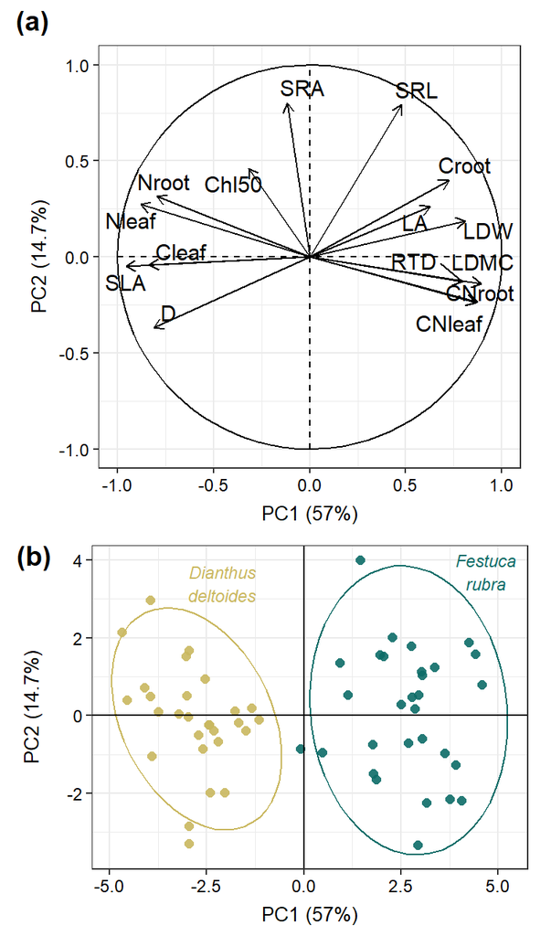

```r
datapca<-data[,c("Treatment", "Species", "LDW", "Chl50", "SLA", "LA", "LDMC", "Nleaf", "Cleaf", "CNleaf", "SRL", "SRA", "RTD", "D", "Nroot", "Croot", "CNroot")]
datapca<-na.omit(datapca)

pca<-PCA(datapca, quali.sup=1:2, scale.unit=T, ncp=2, graph=FALSE)

ind<-data.frame(datapca[,1:2], pca$ind$coord)

cbPalette <- c("#C9B75E", "#0C6C67")

cex.axis<-9
cex.title<-10
cex.pt<-2

plotvar<-plot(pca, choix="var", graph.type = "ggplot")+
      xlab(paste("PC1 (", round(pca$eig[1,2], 1), "%)", sep=""))+
      ylab(paste("PC2 (", round(pca$eig[2,2], 1), "%)", sep=""))+
      theme_bw()+
      theme(axis.title=element_text(size=cex.title, color="black", face="plain"),
            axis.title.y=element_text(margin = margin(t = 0, r = 5, b = 0, l = 0)),
            axis.title.x=element_text(margin = margin(t = 5, r = 0, b = 0, l = 0)),
            axis.text=element_text(size=cex.axis, color="black"),
            strip.text = element_text(size=cex.title, face="italic"),
            strip.background=element_rect(color="black"))+
      ggtitle("")

plotind<-ggplot(ind, aes(x=Dim.1, y=Dim.2, color=Species))+
      theme_bw()+
      geom_point(size=cex.pt, alpha=0.9, shape=16)+
      stat_ellipse()+
      geom_hline(yintercept=0)+
      geom_vline(xintercept=0)+
      scale_color_manual(values=cbPalette, name="Species")+
      xlab(paste("PC1 (", round(pca$eig[1,2], 1), "%)", sep=""))+
      ylab(paste("PC2 (", round(pca$eig[2,2], 1), "%)", sep=""))+
      theme(axis.title=element_text(size=cex.title, color="black", face="plain"),
            axis.title.y=element_text(margin = margin(t = 0, r = 5, b = 0, l = 0)),
            axis.title.x=element_text(margin = margin(t = 5, r = 0, b = 0, l = 0)),
            axis.text=element_text(size=cex.axis, color="black"),
            strip.text = element_text(size=cex.title, face="italic"),
            strip.background=element_rect(color="black"),
            legend.position = "none")+
      coord_fixed()+
      annotate("text", x=-2.1, y=3.4, label="Dianthus\ndeltoides", size=3, color="#C9B75E", fontface="italic")+
      annotate("text", x=4.7, y=3.7, label="Festuca\nrubra", size=3, color="#0C6C67", fontface="italic")

plotpca<-ggarrange(plotvar, plotind, ncol=1, nrow=2, labels=c("(a)", "(b)"), heights=c(1,0.75), align="v")

plotpca
```

```r
#ggsave("PCA_traits.tiff", plotpca, dpi=1000, compression="lzw", width=10, height=17, units="cm")
```

# Biomass production and allocation

## Allometric analysis

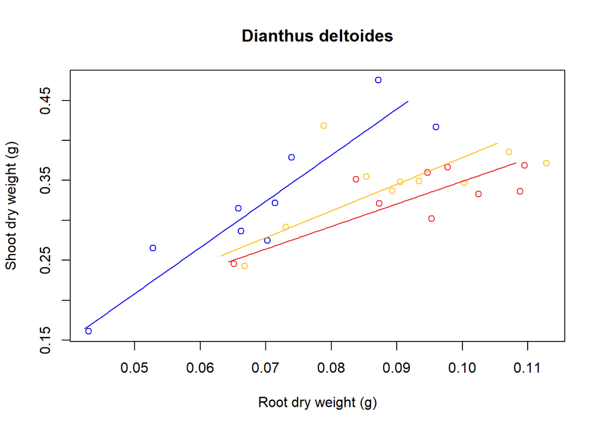

```r
model.dd<-sma(SDW~RDW*Treatment, data[data$Species=="Dianthus deltoides",])
plot(model.dd, main="Dianthus deltoides", xlab="Root dry weight (g)", ylab="Shoot dry weight (g)")
```

```r
summary(model.dd)
```

```
## Call: sma(formula = SDW ~ RDW * Treatment, data = data[data$Species ==
##     "Dianthus deltoides", ])
##
## Fit using Standardized Major Axis
##
## ------------------------------------------------------------
## Results of comparing lines among groups.
##
## H0 : slopes are equal.
## Likelihood ratio statistic : 5.648 with 2 degrees of freedom
## P-value : 0.059371
## ------------------------------------------------------------
##
## Coefficients by group in variable "Treatment"
##
## Group: Forbs
##               elevation    slope
## estimate    -0.07990914 5.769987
## lower limit -0.23002029 4.036826
## upper limit  0.07020202 8.247259
##
## H0 : variables uncorrelated.
## R-squared : 0.8333453
## P-value : 0.00058969
##
## Group: Grasses
##               elevation    slope
## estimate     0.04500752 3.336945
## lower limit -0.15536014 1.796968
## upper limit  0.24537518 6.196659
##
## H0 : variables uncorrelated.
## R-squared : 0.3461831
## P-value : 0.073575
##
## Group: Soil
##               elevation    slope
## estimate     0.06682156 2.820559
## lower limit -0.09873351 1.572121
## upper limit  0.23237664 5.060396
##
## H0 : variables uncorrelated.
## R-squared : 0.5212985
## P-value : 0.028057
```

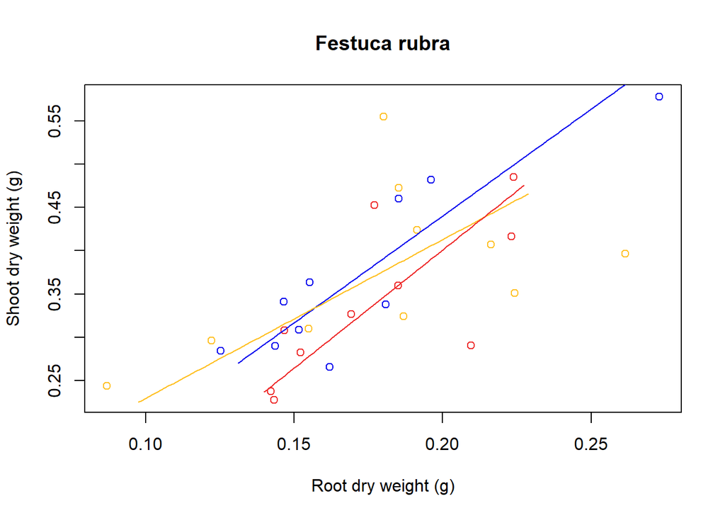

```r
model.fr<-sma(SDW~RDW*Treatment, data[data$Species=="Festuca rubra",])
plot(model.fr, main="Festuca rubra", xlab="Root dry weight (g)", ylab="Shoot dry weight (g)")
```

```r
summary(model.fr)
```

```
## Call: sma(formula = SDW ~ RDW * Treatment, data = data[data$Species ==
##     "Festuca rubra", ])
##
## Fit using Standardized Major Axis
##
## ------------------------------------------------------------
## Results of comparing lines among groups.
##
## H0 : slopes are equal.
## Likelihood ratio statistic : 0.9968 with 2 degrees of freedom
## P-value : 0.60749
## ------------------------------------------------------------
##
## Coefficients by group in variable "Treatment"
##
## Group: Forbs
##               elevation    slope
## estimate    -0.05438684 2.473240
## lower limit -0.21609677 1.721904
## upper limit  0.10732310 3.552415
##
## H0 : variables uncorrelated.
## R-squared : 0.7939741
## P-value : 0.0005394
##
## Group: Grasses
##               elevation    slope
## estimate     0.04550469 1.837395
## lower limit -0.19952211 0.952840
## upper limit  0.29053149 3.543115
##
## H0 : variables uncorrelated.
## R-squared : 0.2525254
## P-value : 0.1388
##
## Group: Soil
##              elevation    slope
## estimate    -0.1460196 2.734179
## lower limit -0.4203633 1.607363
## upper limit  0.1283240 4.650932
##
## H0 : variables uncorrelated.
## R-squared : 0.5339608
## P-value : 0.016371
```

## Plot results

```r
stat_sdw<-bootstrap_mean(response="SDW", data=data, n_perm=10000)
knitr::kable(stat_sdw, caption="Results for shoot dry weight (mean in g, ES in %)")
```

Results for shoot dry weight (mean in g, ES in %)

| Species | Treatment | lowCI | mean | highCI | ES |
| --- | --- | --- | --- | --- | --- |
| Dianthus deltoides | Forbs | 0.2652614 | 0.3217589 | 0.3793613 | -2.967766 |
| Dianthus deltoides | Grasses | 0.3142593 | 0.3445250 | 0.3715220 | 3.897768 |
| Dianthus deltoides | Soil | 0.3053720 | 0.3316000 | 0.3530467 | 0.000000 |
| Festuca rubra | Forbs | 0.3152399 | 0.3710080 | 0.4341197 | 9.574735 |
| Festuca rubra | Grasses | 0.3252150 | 0.3780990 | 0.4328203 | 11.669015 |
| Festuca rubra | Soil | 0.2883043 | 0.3385890 | 0.3914441 | 0.000000 |

```r
stat_rdw<-bootstrap_mean(response="RDW", data=data, n_perm=10000)
knitr::kable(stat_rdw, caption="Results for root dry weight (mean in g, ES in %)")
```

Results for root dry weight (mean in g, ES in %)

| Species | Treatment | lowCI | mean | highCI | ES |
| --- | --- | --- | --- | --- | --- |
| Dianthus deltoides | Forbs | 0.0597077 | 0.0696133 | 0.0794127 | -25.844213 |
| Dianthus deltoides | Grasses | 0.0809197 | 0.0897580 | 0.0984111 | -4.385053 |
| Dianthus deltoides | Soil | 0.0847731 | 0.0938744 | 0.1017156 | 0.000000 |
| Festuca rubra | Forbs | 0.1508264 | 0.1719990 | 0.1986887 | -2.957555 |
| Festuca rubra | Grasses | 0.1507078 | 0.1810140 | 0.2100496 | 2.128740 |
| Festuca rubra | Soil | 0.1592710 | 0.1772410 | 0.1970379 | 0.000000 |

```r
stat_smf<-bootstrap_mean(response="SMF", data=data, n_perm=10000)
knitr::kable(stat_smf, caption="Results for shoot mass fraction (mean in mg/g, ES in %)")
```

Results for shoot mass fraction (mean in mg/g, ES in %)

| Species | Treatment | lowCI | mean | highCI | ES |
| --- | --- | --- | --- | --- | --- |
| Dianthus deltoides | Forbs | 807.5757 | 819.1854 | 830.4468 | 5.078361 |
| Dianthus deltoides | Grasses | 782.3825 | 792.9484 | 806.2877 | 1.712896 |
| Dianthus deltoides | Soil | 768.9324 | 779.5947 | 790.5220 | 0.000000 |
| Festuca rubra | Forbs | 662.0713 | 680.7609 | 696.6558 | 4.417681 |
| Festuca rubra | Grasses | 645.7926 | 677.4044 | 708.2219 | 3.902844 |
| Festuca rubra | Soil | 628.6142 | 651.9594 | 674.4543 | 0.000000 |

```r
stat_rmf<-bootstrap_mean(response="RMF", data=data, n_perm=10000)
knitr::kable(stat_rmf, caption="Results for root mass fraction (mean in mg/g, ES in %)")
```

Results for root mass fraction (mean in mg/g, ES in %)

| Species | Treatment | lowCI | mean | highCI | ES |
| --- | --- | --- | --- | --- | --- |
| Dianthus deltoides | Forbs | 169.5532 | 180.8146 | 192.4243 | -17.962654 |
| Dianthus deltoides | Grasses | 193.7123 | 207.0516 | 217.6175 | -6.058679 |
| Dianthus deltoides | Soil | 209.4780 | 220.4053 | 231.0676 | 0.000000 |
| Festuca rubra | Forbs | 303.3442 | 319.2391 | 337.9287 | -8.275325 |
| Festuca rubra | Grasses | 291.7781 | 322.5956 | 354.2074 | -7.310917 |
| Festuca rubra | Soil | 325.5457 | 348.0406 | 371.3858 | 0.000000 |

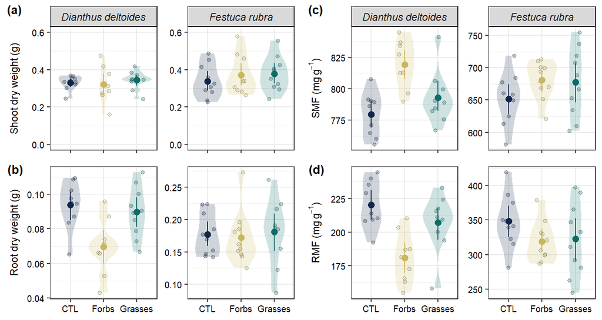

```r
cbPalette <- c("#C9B75E", "#0C6C67", "#11264B")

cex.axis<-7.5
cex.title<-8.5
cex.pt<-1.2

#SDW: shoot dry weight

sdw<-ggplot(data, aes(x=Treatment, y=SDW, fill=Treatment))+
  facet_wrap(~Species, scales="free_y")+
  stat_ydensity(color=adjustcolor("white", alpha.f = 0.1), alpha=0.2)+
  geom_jitter(aes(x=Treatment, y=SDW, fill=Treatment), shape=21, size=cex.pt, alpha=0.3,
              position=position_jitter(width=0.2))+
  stat_summary(aes(x=Treatment, y=SDW, color=Treatment),
               fun.data="mean_cl_boot", fun.args = list(B=10000), size=0.5, shape=16)+
  theme_bw()+
  xlab("")+
  ylab("Shoot dry weight (g)")+
  theme(axis.title=element_text(size=cex.title, color="black", face="plain"),
        axis.title.y=element_text(margin = margin(t = 0, r = 3, b = 0, l = 0)),
        axis.title.x=element_blank(),
        axis.text=element_text(size=cex.axis, color="black"),
        axis.text.x=element_blank(),
        legend.position = "none",
        strip.text = element_text(size=cex.title, face="italic"),
        strip.background=element_rect(color="black"))+
  scale_x_discrete(limits=c("Soil", "Forbs", "Grasses"),
                   labels=c("CTL", "Forbs", "Grasses"))+
  scale_y_continuous(limits=c(0,0.6), breaks=seq(0,0.6,by=0.2))+
  scale_fill_manual(values=cbPalette)+
  scale_color_manual(values=cbPalette)

#RDW: root dry weight

rdw<-ggplot(data, aes(x=Treatment, y=RDW, fill=Treatment))+
  facet_wrap(~Species, scales="free_y")+
  stat_ydensity(color=adjustcolor("white", alpha.f = 0.1), alpha=0.2)+
  geom_jitter(aes(x=Treatment, y=RDW, fill=Treatment), shape=21, size=cex.pt, alpha=0.3,
              position=position_jitter(width=0.2))+
  stat_summary(aes(x=Treatment, y=RDW, color=Treatment),
               fun.data="mean_cl_boot", fun.args = list(B=10000), size=0.5, shape=16)+
  theme_bw()+
  xlab("")+
  ylab("Root dry weight (g)")+
  theme(axis.title=element_text(size=cex.title, color="black", face="plain"),
        axis.title.y=element_text(margin = margin(t = 0, r = 3, b = 0, l = 0)),
        axis.title.x=element_blank(),
        axis.text=element_text(size=cex.axis, color="black"),
        legend.position = "none",
        strip.text = element_blank(),
        strip.background=element_blank())+
  scale_x_discrete(limits=c("Soil", "Forbs", "Grasses"),
                   labels=c("CTL", "Forbs", "Grasses"))+
  scale_fill_manual(values=cbPalette)+
  scale_color_manual(values=cbPalette)

#SMF: shoot mass fraction

smf<-ggplot(data, aes(x=Treatment, y=SMF, fill=Treatment))+
  facet_wrap(~Species, scales="free_y")+
  stat_ydensity(color=adjustcolor("white", alpha.f = 0.1), alpha=0.2)+
  geom_jitter(aes(x=Treatment, y=SMF, fill=Treatment), shape=21, size=cex.pt, alpha=0.3,
              position=position_jitter(width=0.2))+
  stat_summary(aes(x=Treatment, y=SMF, color=Treatment),
               fun.data="mean_cl_boot", fun.args = list(B=10000), size=0.5, shape=16)+
  theme_bw()+
  xlab("")+
  ylab(expression(paste("SMF (mg ", g^-1, ")")))+
  theme(axis.title=element_text(size=cex.title, color="black", face="plain"),
        axis.title.y=element_text(margin = margin(t = 0, r = 3, b = 0, l = 0)),
        axis.title.x=element_blank(),
        axis.text=element_text(size=cex.axis, color="black"),
        axis.text.x=element_blank(),
        legend.position = "none",
        strip.text = element_text(size=cex.title, face="italic"),
        strip.background=element_rect(color="black"))+
  scale_x_discrete(limits=c("Soil", "Forbs", "Grasses"),
                   labels=c("CTL", "Forbs", "Grasses"))+
  scale_fill_manual(values=cbPalette)+
  scale_color_manual(values=cbPalette)

#RMF: root mass fraction

rmf<-ggplot(data, aes(x=Treatment, y=RMF, fill=Treatment))+
  facet_wrap(~Species, scales="free_y")+
  stat_ydensity(color=adjustcolor("white", alpha.f = 0.1), alpha=0.2)+
  geom_jitter(aes(x=Treatment, y=RMF, fill=Treatment), shape=21, size=cex.pt, alpha=0.3,
              position=position_jitter(width=0.2))+
  stat_summary(aes(x=Treatment, y=RMF, color=Treatment),
               fun.data="mean_cl_boot", fun.args = list(B=10000), size=0.5, shape=16)+
  theme_bw()+
  xlab("")+
  ylab(expression(paste("RMF (mg ", g^-1, ")")))+
  theme(axis.title=element_text(size=cex.title, color="black", face="plain"),
        axis.title.y=element_text(margin = margin(t = 0, r = 3, b = 0, l = 0)),
        axis.title.x=element_blank(),
        axis.text=element_text(size=cex.axis, color="black"),
        legend.position = "none",
        strip.text = element_blank(),
        strip.background=element_blank())+
  scale_x_discrete(limits=c("Soil", "Forbs", "Grasses"),
                   labels=c("CTL", "Forbs", "Grasses"))+
  scale_fill_manual(values=cbPalette)+
  scale_color_manual(values=cbPalette)

p<-ggarrange(sdw, smf, rdw, rmf, nrow=2, ncol=2, align="v", labels=c("(a)", "(c)", "(b)", "(d)"),
             font.label=list(size=10))
p
```

```r
#ggsave("Biomass_production_allocation.tiff", p, dpi=1000, compression="lzw", width=18, height=18/(15/8), units="cm")
```

## Plot unstandardised effect sizes

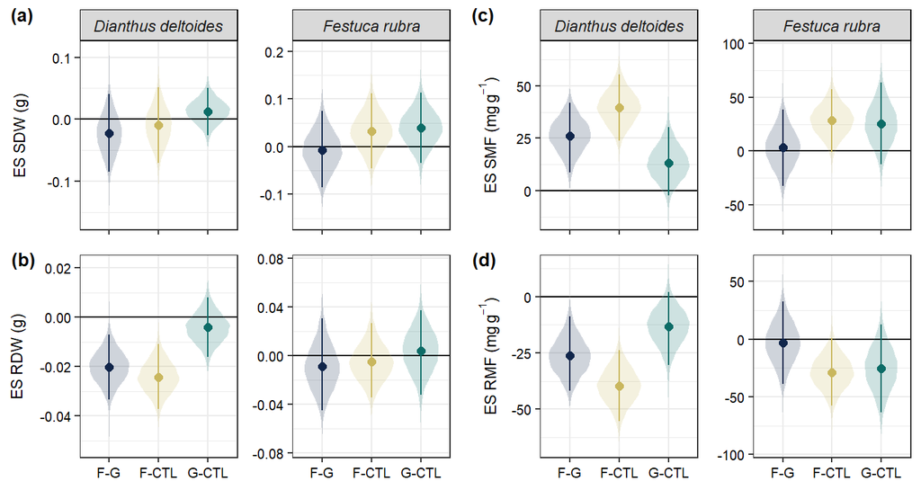

```r
es_sdw<-bootstrap_ES(response="SDW", data=data, n_perm=10000, plot=FALSE)
es_rdw<-bootstrap_ES(response="RDW", data=data, n_perm=10000, plot=FALSE)
es_smf<-bootstrap_ES(response="SMF", data=data, n_perm=10000, plot=FALSE)
es_rmf<-bootstrap_ES(response="RMF", data=data, n_perm=10000, plot=FALSE)

cex.axis<-7.5
cex.title<-8.5
cex.pt<-1.2
cex.mean<-2

cbPalette <- c("#11264B", "#C9B75E", "#0C6C67")

#SDW: shoot dry weight

sdw<-ggplot(data)+
  facet_wrap(~Species, scales="free_y")+
  geom_hline(yintercept = 0)+
  stat_ydensity(data=es_sdw$bootstrap, aes(x=Contrast, y=ES, fill=Contrast),
                color=adjustcolor("white", alpha.f = 0.1), alpha=0.2, inherit.aes = FALSE)+
  geom_segment(data=es_sdw$summary, aes(x=Contrast, xend=Contrast, y=lowCI, yend=highCI, color=Contrast),
               size=0.5, inherit.aes = F)+
  geom_point(data=es_sdw$summary, mapping=aes(x=Contrast, y=ES, color=Contrast, fill=Contrast),
             shape=21, size=cex.mean, inherit.aes = F)+
  theme_bw()+
  xlab("")+
  ylab("ES SDW (g)")+
  theme(axis.title=element_text(size=cex.title, color="black", face="plain"),
        axis.title.y=element_text(margin = margin(t = 0, r = 2, b = 0, l = 0)),
        axis.title.x=element_blank(),
        axis.text=element_text(size=cex.axis, color="black"),
        axis.text.x=element_blank(),
        legend.position = "none",
        strip.text = element_text(size=cex.title, face="italic"),
        strip.background=element_rect(color="black"))+
  scale_x_discrete(limits=c("Forbs-Grasses", "Forbs-Soil", "Grasses-Soil"),
                   labels=c("F-G", "F-CTL", "G-CTL"))+
  scale_fill_manual(values=cbPalette)+
  scale_color_manual(values=cbPalette)

#RDW: root dry weight

rdw<-ggplot(data)+
  facet_wrap(~Species, scales="free_y")+
  geom_hline(yintercept = 0)+
  stat_ydensity(data=es_rdw$bootstrap, aes(x=Contrast, y=ES, fill=Contrast),
                color=adjustcolor("white", alpha.f = 0.1), alpha=0.2, inherit.aes = FALSE)+
  geom_segment(data=es_rdw$summary, aes(x=Contrast, xend=Contrast, y=lowCI, yend=highCI, color=Contrast),
               size=0.5, inherit.aes = F)+
  geom_point(data=es_rdw$summary, mapping=aes(x=Contrast, y=ES, color=Contrast, fill=Contrast),
             shape=21, size=cex.mean, inherit.aes = F)+
  theme_bw()+
  xlab("")+
  ylab("ES RDW (g)")+
  theme(axis.title=element_text(size=cex.title, color="black", face="plain"),
        axis.title.y=element_text(margin = margin(t = 0, r = 5, b = 0, l = 0)),
        axis.title.x=element_blank(),
        axis.text=element_text(size=cex.axis, color="black"),
        legend.position = "none",
        strip.text = element_blank(),
        strip.background=element_blank())+
  scale_x_discrete(limits=c("Forbs-Grasses", "Forbs-Soil", "Grasses-Soil"),
                   labels=c("F-G", "F-CTL", "G-CTL"))+
  scale_fill_manual(values=cbPalette)+
  scale_color_manual(values=cbPalette)

#SMF: shoot mass fraction

smf<-ggplot(data)+
  facet_wrap(~Species, scales="free_y")+
  geom_hline(yintercept = 0)+
  stat_ydensity(data=es_smf$bootstrap, aes(x=Contrast, y=ES, fill=Contrast),
                color=adjustcolor("white", alpha.f = 0.1), alpha=0.2, inherit.aes = FALSE)+
  geom_segment(data=es_smf$summary, aes(x=Contrast, xend=Contrast, y=lowCI, yend=highCI, color=Contrast),
               size=0.5, inherit.aes = F)+
  geom_point(data=es_smf$summary, mapping=aes(x=Contrast, y=ES, color=Contrast, fill=Contrast),
             shape=21, size=cex.mean, inherit.aes = F)+
  theme_bw()+
  xlab("")+
  ylab(expression(paste("ES SMF (mg ", g^-1, ")")))+
  theme(axis.title=element_text(size=cex.title, color="black", face="plain"),
        axis.title.y=element_text(margin = margin(t = 0, r = -8, b = 0, l = 0)),
        axis.title.x=element_blank(),
        axis.text=element_text(size=cex.axis, color="black"),
        axis.text.x=element_blank(),
        legend.position = "none",
        strip.text = element_text(size=cex.title, face="italic"),
        strip.background=element_rect(color="black"))+
  scale_x_discrete(limits=c("Forbs-Grasses", "Forbs-Soil", "Grasses-Soil"),
                   labels=c("F-G", "F-CTL", "G-CTL"))+
  scale_fill_manual(values=cbPalette)+
  scale_color_manual(values=cbPalette)

#RMF: root mass fraction

rmf<-ggplot(data)+
  facet_wrap(~Species, scales="free_y")+
  geom_hline(yintercept = 0)+
  stat_ydensity(data=es_rmf$bootstrap, aes(x=Contrast, y=ES, fill=Contrast),
                color=adjustcolor("white", alpha.f = 0.1), alpha=0.2, inherit.aes = FALSE)+
  geom_segment(data=es_rmf$summary, aes(x=Contrast, xend=Contrast, y=lowCI, yend=highCI, color=Contrast),
               size=0.5, inherit.aes = F)+
  geom_point(data=es_rmf$summary, mapping=aes(x=Contrast, y=ES, color=Contrast, fill=Contrast),
             shape=21, size=cex.mean, inherit.aes = F)+
  theme_bw()+
  xlab("")+
  ylab(expression(paste("ES RMF (mg ", g^-1, ")")))+
  theme(axis.title=element_text(size=cex.title, color="black", face="plain"),
        axis.title.y=element_text(margin = margin(t = 0, r = -8, b = 0, l = 0)),
        axis.title.x=element_blank(),
        axis.text=element_text(size=cex.axis, color="black"),
        legend.position = "none",
        strip.text = element_blank(),
        strip.background=element_blank())+
  scale_x_discrete(limits=c("Forbs-Grasses", "Forbs-Soil", "Grasses-Soil"),
                   labels=c("F-G", "F-CTL", "G-CTL"))+
  scale_fill_manual(values=cbPalette)+
  scale_color_manual(values=cbPalette)

p<-ggarrange(sdw, smf, rdw, rmf, nrow=2, ncol=2, align="v", labels=c("(a)", "(c)", "(b)", "(d)"),
             font.label=list(size=10))
p
```

```r
#ggsave("Biomass_production_allocation_ES.tiff", p, dpi=1000, compression="lzw", width=18, height=18/(15/8), units="cm")
```

# Leaf functional traits

## Plot results

```r
stat_ldw<-bootstrap_mean(response="LDW", data=data, n_perm=10000)
knitr::kable(stat_ldw, caption="Results for dry weight of a leaf (mean in mg, ES in %)")
```

Results for dry weight of a leaf (mean in mg, ES in %)

| Species | Treatment | lowCI | mean | highCI | ES |
| --- | --- | --- | --- | --- | --- |
| Dianthus deltoides | Forbs | 1.545333 | 2.018778 | 2.432011 | 13.648589 |
| Dianthus deltoides | Grasses | 1.678268 | 2.196000 | 2.792530 | 23.625446 |
| Dianthus deltoides | Soil | 1.355647 | 1.776333 | 2.267144 | 0.000000 |
| Festuca rubra | Forbs | 8.127318 | 10.035100 | 11.817253 | 1.777926 |
| Festuca rubra | Grasses | 6.358200 | 8.776700 | 11.608000 | -10.985010 |
| Festuca rubra | Soil | 7.914495 | 9.859800 | 12.469553 | 0.000000 |

```r
stat_chl50<-bootstrap_mean(response="Chl50", data=data, n_perm=10000)
knitr::kable(stat_chl50, caption="Results for leaf chlorophyll concentration (mean in mg/m², ES in %)")
```

Results for leaf chlorophyll concentration (mean in mg/m², ES in %)

| Species | Treatment | lowCI | mean | highCI | ES |
| --- | --- | --- | --- | --- | --- |
| Dianthus deltoides | Forbs | 426.6667 | 442.7778 | 457.4444 | -0.9445687 |
| Dianthus deltoides | Grasses | 436.3000 | 454.6000 | 475.0000 | 1.7002237 |
| Dianthus deltoides | Soil | 425.8889 | 447.0000 | 470.2222 | 0.0000000 |
| Festuca rubra | Forbs | 393.7000 | 425.2000 | 454.5000 | -4.4709054 |
| Festuca rubra | Grasses | 420.2975 | 433.0000 | 446.4000 | -2.7184902 |
| Festuca rubra | Soil | 419.8000 | 445.1000 | 472.2025 | 0.0000000 |

```r
stat_sla<-bootstrap_mean(response="SLA", data=data, n_perm=10000)
knitr::kable(stat_sla, caption="Results for specific leaf area (mean in cm²/g, ES in %)")
```

Results for specific leaf area (mean in cm²/g, ES in %)

| Species | Treatment | lowCI | mean | highCI | ES |
| --- | --- | --- | --- | --- | --- |
| Dianthus deltoides | Forbs | 248.6479 | 263.8536 | 279.8500 | -4.5170546 |
| Dianthus deltoides | Grasses | 243.5619 | 263.8826 | 282.4570 | -4.5065513 |
| Dianthus deltoides | Soil | 256.1368 | 276.3358 | 295.9444 | 0.0000000 |
| Festuca rubra | Forbs | 112.1728 | 120.5198 | 129.3684 | -4.1011962 |
| Festuca rubra | Grasses | 115.4426 | 126.3718 | 138.3259 | 0.5552897 |
| Festuca rubra | Soil | 118.1287 | 125.6739 | 133.3600 | 0.0000000 |

```r
stat_la<-bootstrap_mean(response="LA", data=data, n_perm=10000)
knitr::kable(stat_la, caption="Results for area of a leaf (mean in cm², ES in %)")
```

Results for area of a leaf (mean in cm², ES in %)

| Species | Treatment | lowCI | mean | highCI | ES |
| --- | --- | --- | --- | --- | --- |
| Dianthus deltoides | Forbs | 0.4099642 | 0.5240800 | 0.6193772 | 10.87755 |
| Dianthus deltoides | Grasses | 0.4625890 | 0.5537410 | 0.6581172 | 17.15281 |
| Dianthus deltoides | Soil | 0.3917167 | 0.4726656 | 0.5633160 | 0.00000 |
| Festuca rubra | Forbs | 0.9785396 | 1.1925480 | 1.4089502 | -5.49554 |
| Festuca rubra | Grasses | 0.8055555 | 1.0691790 | 1.4198659 | -15.27202 |
| Festuca rubra | Soil | 0.9728996 | 1.2618960 | 1.6950456 | 0.00000 |

```r
stat_ldmc<-bootstrap_mean(response="LDMC", data=data, n_perm=10000)
knitr::kable(stat_ldmc, caption="Results for leaf dry matter content (mean in mg/g, ES in %)")
```

Results for leaf dry matter content (mean in mg/g, ES in %)

| Species | Treatment | lowCI | mean | highCI | ES |
| --- | --- | --- | --- | --- | --- |
| Dianthus deltoides | Forbs | 226.7776 | 237.1787 | 248.1726 | 3.9847382 |
| Dianthus deltoides | Grasses | 216.8142 | 227.7873 | 241.3552 | -0.1326747 |
| Dianthus deltoides | Soil | 219.4497 | 228.0900 | 236.0577 | 0.0000000 |
| Festuca rubra | Forbs | 267.5965 | 284.2018 | 301.4760 | 1.7746659 |
| Festuca rubra | Grasses | 266.7227 | 283.4291 | 301.1662 | 1.4979364 |
| Festuca rubra | Soil | 265.7828 | 279.2461 | 291.2125 | 0.0000000 |

```r
stat_nleaf<-bootstrap_mean(response="Nleaf", data=data, n_perm=10000)
knitr::kable(stat_nleaf, caption="Results for leaf N concentration (mean in mg/g, ES in %)")
```

Results for leaf N concentration (mean in mg/g, ES in %)

| Species | Treatment | lowCI | mean | highCI | ES |
| --- | --- | --- | --- | --- | --- |
| Dianthus deltoides | Forbs | 24.98861 | 28.76667 | 32.67778 | 3.934163 |
| Dianthus deltoides | Grasses | 25.93000 | 28.54000 | 31.18000 | 3.115215 |
| Dianthus deltoides | Soil | 24.58889 | 27.67778 | 30.81111 | 0.000000 |
| Festuca rubra | Forbs | 15.25500 | 17.16000 | 19.32525 | -13.201821 |
| Festuca rubra | Grasses | 16.30000 | 18.58000 | 21.08000 | -6.019221 |
| Festuca rubra | Soil | 17.25487 | 19.77000 | 22.46000 | 0.000000 |

```r
stat_cleaf<-bootstrap_mean(response="Cleaf", data=data, n_perm=10000)
knitr::kable(stat_cleaf, caption="Results for leaf C concentration (mean in mg/g, ES in %)")
```

Results for leaf C concentration (mean in mg/g, ES in %)

| Species | Treatment | lowCI | mean | highCI | ES |
| --- | --- | --- | --- | --- | --- |
| Dianthus deltoides | Forbs | 444.0997 | 451.7556 | 457.2228 | -0.6451298 |
| Dianthus deltoides | Grasses | 449.9000 | 454.3700 | 458.2000 | -0.0701334 |
| Dianthus deltoides | Soil | 451.6778 | 454.6889 | 457.7556 | 0.0000000 |
| Festuca rubra | Forbs | 433.7500 | 435.7400 | 437.7150 | -0.2655070 |
| Festuca rubra | Grasses | 434.4200 | 436.3600 | 438.2600 | -0.1235981 |
| Festuca rubra | Soil | 434.6600 | 436.9000 | 439.1450 | 0.0000000 |

```r
stat_cnleaf<-bootstrap_mean(response="CNleaf", data=data, n_perm=10000)
knitr::kable(stat_cnleaf, caption="Results for leaf C:N (ES in %)")
```

Results for leaf C:N (ES in %)

| Species | Treatment | lowCI | mean | highCI | ES |
| --- | --- | --- | --- | --- | --- |
| Dianthus deltoides | Forbs | 14.24777 | 16.37967 | 18.61461 | -2.986666 |
| Dianthus deltoides | Grasses | 14.77772 | 16.26654 | 17.80666 | -3.656691 |
| Dianthus deltoides | Soil | 15.08432 | 16.88393 | 18.78149 | 0.000000 |
| Festuca rubra | Forbs | 23.43172 | 26.22839 | 28.98078 | 13.602588 |
| Festuca rubra | Grasses | 21.57036 | 24.44365 | 27.43443 | 5.872353 |
| Festuca rubra | Soil | 20.14095 | 23.08785 | 26.26730 | 0.000000 |

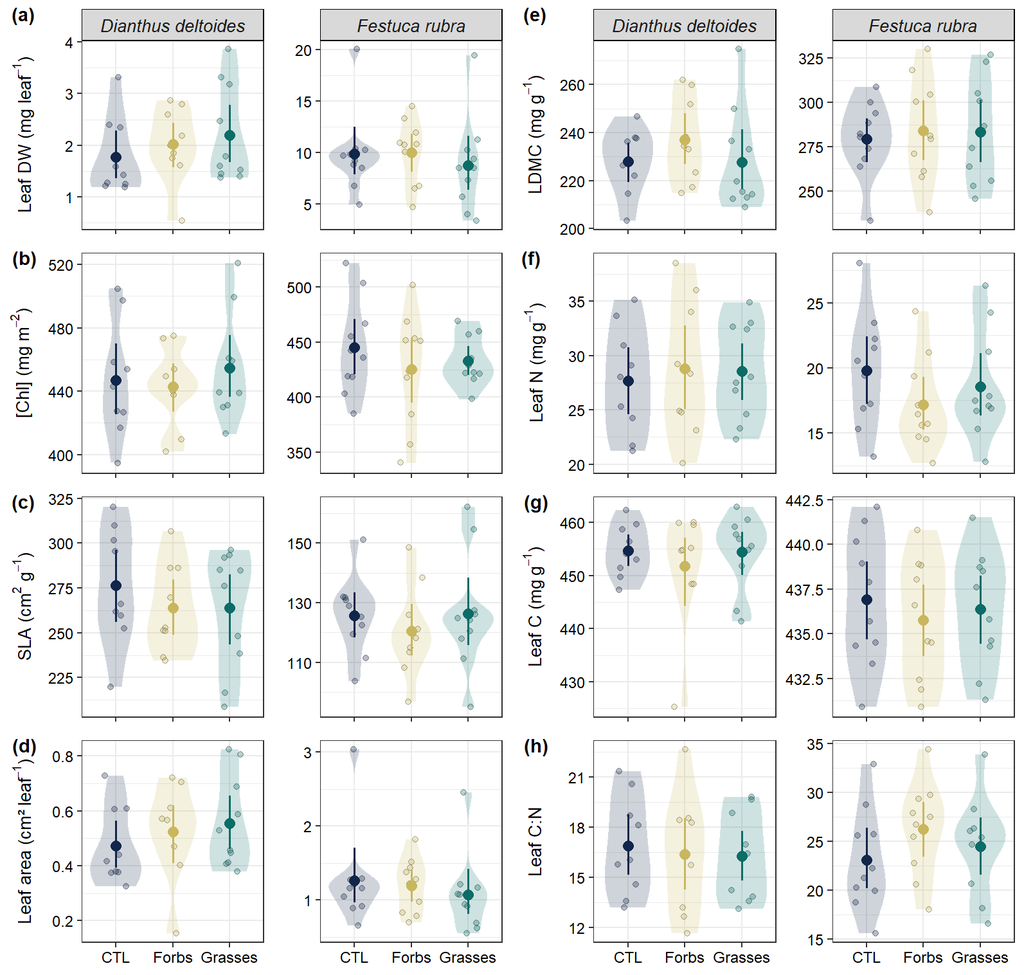

```r
cex.axis<-9
cex.title<-10
cex.pt<-1.5

cbPalette <- c("#C9B75E", "#0C6C67", "#11264B")

#LDW

p1<-ggplot(data, aes(x=Treatment, y=LDW, fill=Treatment))+
  facet_wrap(~Species, scales="free_y")+
  stat_ydensity(color=adjustcolor("white", alpha.f = 0.1), alpha=0.2)+
  geom_jitter(aes(x=Treatment, y=LDW, fill=Treatment), shape=21, size=cex.pt, alpha=0.3,
              position=position_jitter(width=0.2))+
  stat_summary(aes(x=Treatment, y=LDW, color=Treatment),
               fun.data="mean_cl_boot", fun.args = list(B=10000), size=0.6, shape=16)+
  theme_bw()+
  xlab("")+
  ylab(expression(paste("Leaf DW (mg ", leaf^-1, ")", sep="")))+
  theme(axis.title=element_text(size=cex.title, color="black", face="plain"),
        axis.title.y=element_text(margin = margin(t = 0, r = 5, b = 0, l = 0)),
        axis.title.x=element_blank(),
        axis.text=element_text(size=cex.axis, color="black"),
        axis.text.x = element_blank(),
        legend.position = "none",
        strip.text = element_text(size=10, face="italic"),
        strip.background=element_rect(color="black"))+
  scale_x_discrete(limits=c("Soil", "Forbs", "Grasses"),
                   labels=c("CTL", "Forbs", "Grasses"))+
  scale_fill_manual(values=cbPalette)+
  scale_color_manual(values=cbPalette)

#Chl50

p2<-ggplot(data, aes(x=Treatment, y=Chl50, fill=Treatment))+
  facet_wrap(~Species, scales="free_y")+
  stat_ydensity(color=adjustcolor("white", alpha.f = 0.1), alpha=0.2)+
  geom_jitter(aes(x=Treatment, y=Chl50, fill=Treatment), shape=21, size=cex.pt, alpha=0.3,
              position=position_jitter(width=0.2))+
  stat_summary(aes(x=Treatment, y=Chl50, color=Treatment),
               fun.data="mean_cl_boot", fun.args = list(B=10000), size=0.6, shape=16)+
  theme_bw()+
  xlab("")+
  ylab(expression(paste("[Chl] (mg ", m^-2, ")", sep="")))+
  theme(axis.title=element_text(size=cex.title, color="black", face="plain"),
        axis.title.y=element_text(margin = margin(t = 0, r = 7, b = 0, l = 0)),
        axis.title.x=element_blank(),
        axis.text=element_text(size=cex.axis, color="black"),
        axis.text.x = element_blank(),
        legend.position = "none",
        strip.text = element_blank(),
        strip.background=element_blank())+
  scale_x_discrete(limits=c("Soil", "Forbs", "Grasses"),
                   labels=c("CTL", "Forbs", "Grasses"))+
  scale_fill_manual(values=cbPalette)+
  scale_color_manual(values=cbPalette)

#SLA

p3<-ggplot(data, aes(x=Treatment, y=SLA, fill=Treatment))+
  facet_wrap(~Species, scales="free_y")+
  stat_ydensity(color=adjustcolor("white", alpha.f = 0.1), alpha=0.2)+
  geom_jitter(aes(x=Treatment, y=SLA, fill=Treatment), shape=21, size=cex.pt, alpha=0.3,
              position=position_jitter(width=0.2))+
  stat_summary(aes(x=Treatment, y=SLA, color=Treatment),
               fun.data="mean_cl_boot", fun.args = list(B=10000), size=0.6, shape=16)+
  theme_bw()+
  xlab("")+
  ylab(expression(paste("SLA (", cm^2, " ", g^-1, ")", sep="")))+
  theme(axis.title=element_text(size=cex.title, color="black", face="plain"),
        axis.title.y=element_text(vjust=0.5, margin = margin(t = 0, r = 7, b = 0, l = 0)),
        axis.title.x=element_blank(),
        axis.text=element_text(size=cex.axis, color="black"),
        axis.text.x = element_blank(),
        legend.position = "none",
        strip.text = element_blank(),
        strip.background=element_blank())+
  scale_x_discrete(limits=c("Soil", "Forbs", "Grasses"),
                   labels=c("CTL", "Forbs", "Grasses"))+
  scale_fill_manual(values=cbPalette)+
  scale_color_manual(values=cbPalette)

#LA

p4<-ggplot(data, aes(x=Treatment, y=LA, fill=Treatment))+
  facet_wrap(~Species, scales="free_y")+
  stat_ydensity(color=adjustcolor("white", alpha.f = 0.1), alpha=0.2)+
  geom_jitter(aes(x=Treatment, y=LA, fill=Treatment), shape=21, size=cex.pt, alpha=0.3,
              position=position_jitter(width=0.2))+
  stat_summary(aes(x=Treatment, y=LA, color=Treatment),
               fun.data="mean_cl_boot", fun.args = list(B=10000), size=0.6, shape=16)+
  theme_bw()+
  xlab("")+
  ylab(expression(paste("Leaf area (cm² ", leaf^-1, ")", sep="")))+
  theme(axis.title=element_text(size=cex.title, color="black", face="plain"),
        axis.title.y=element_text(margin = margin(t = 0, r = 5, b = 0, l = 0)),
        axis.title.x=element_blank(),
        axis.text=element_text(size=cex.axis, color="black"),
        legend.position = "none",
        strip.text = element_blank(),
        strip.background=element_blank())+
  scale_x_discrete(limits=c("Soil", "Forbs", "Grasses"),
                   labels=c("CTL", "Forbs", "Grasses"))+
  scale_fill_manual(values=cbPalette)+
  scale_color_manual(values=cbPalette)

#LDMC

p5<-ggplot(data, aes(x=Treatment, y=LDMC, fill=Treatment))+
  facet_wrap(~Species, scales="free_y")+
  stat_ydensity(color=adjustcolor("white", alpha.f = 0.1), alpha=0.2)+
  geom_jitter(aes(x=Treatment, y=LDMC, fill=Treatment), shape=21, size=cex.pt, alpha=0.3,
              position=position_jitter(width=0.2))+
  stat_summary(aes(x=Treatment, y=LDMC, color=Treatment),
               fun.data="mean_cl_boot", fun.args = list(B=10000), size=0.6, shape=16)+
  theme_bw()+
  xlab("")+
  ylab(expression(paste("LDMC (mg ", g^-1, ")", sep="")))+
  theme(axis.title=element_text(size=cex.title, color="black", face="plain"),
        axis.title.y=element_text(margin = margin(t = 0, r = 7, b = 0, l = 0)),
        axis.title.x=element_blank(),
        axis.text=element_text(size=cex.axis, color="black"),
        axis.text.x = element_blank(),
        legend.position = "none",
        strip.text = element_text(size=10, face="italic"),
        strip.background=element_rect(color="black"))+
  scale_x_discrete(limits=c("Soil", "Forbs", "Grasses"),
                   labels=c("CTL", "Forbs", "Grasses"))+
  scale_fill_manual(values=cbPalette)+
  scale_color_manual(values=cbPalette)

#Nleaf

p6<-ggplot(data, aes(x=Treatment, y=Nleaf, fill=Treatment))+
  facet_wrap(~Species, scales="free_y")+
  stat_ydensity(color=adjustcolor("white", alpha.f = 0.1), alpha=0.2)+
  geom_jitter(aes(x=Treatment, y=Nleaf, fill=Treatment), shape=21, size=cex.pt, alpha=0.3,
              position=position_jitter(width=0.2))+
  stat_summary(aes(x=Treatment, y=Nleaf, color=Treatment),
               fun.data="mean_cl_boot", fun.args = list(B=10000), size=0.6, shape=16)+
  theme_bw()+
  xlab("")+
  ylab(expression(paste("Leaf N (mg ", g^-1, ")", sep="")))+
  theme(axis.title=element_text(size=cex.title, color="black", face="plain"),
        axis.title.y=element_text(margin = margin(t = 0, r = 5, b = 0, l = 0)),
        axis.title.x=element_blank(),
        axis.text=element_text(size=cex.axis, color="black"),
        axis.text.x = element_blank(),
        legend.position = "none",
        strip.text = element_blank(),
        strip.background=element_blank())+
  scale_x_discrete(limits=c("Soil", "Forbs", "Grasses"),
                   labels=c("CTL", "Forbs", "Grasses"))+
  scale_fill_manual(values=cbPalette)+
  scale_color_manual(values=cbPalette)

#Cleaf

p7<-ggplot(data, aes(x=Treatment, y=Cleaf, fill=Treatment))+
  facet_wrap(~Species, scales="free_y")+
  stat_ydensity(color=adjustcolor("white", alpha.f = 0.1), alpha=0.2)+
  geom_jitter(aes(x=Treatment, y=Cleaf, fill=Treatment), shape=21, size=cex.pt, alpha=0.3,
              position=position_jitter(width=0.2))+
  stat_summary(aes(x=Treatment, y=Cleaf, color=Treatment),
               fun.data="mean_cl_boot", fun.args = list(B=10000), size=0.6, shape=16)+
  theme_bw()+
  xlab("")+
  ylab(expression(paste("Leaf C (mg ", g^-1, ")", sep="")))+
  theme(axis.title=element_text(size=cex.title, color="black", face="plain"),
        axis.title.y=element_text(margin = margin(t = 0, r = 7, b = 0, l = 0)),
        axis.title.x=element_blank(),
        axis.text=element_text(size=cex.axis, color="black"),
        axis.text.x = element_blank(),
        legend.position = "none",
        strip.text = element_blank(),
        strip.background=element_blank())+
  scale_x_discrete(limits=c("Soil", "Forbs", "Grasses"),
                   labels=c("CTL", "Forbs", "Grasses"))+
  scale_fill_manual(values=cbPalette)+
  scale_color_manual(values=cbPalette)

#CN ratio

p8<-ggplot(data, aes(x=Treatment, y=CNleaf, fill=Treatment))+
  facet_wrap(~Species, scales="free_y")+
  stat_ydensity(color=adjustcolor("white", alpha.f = 0.1), alpha=0.2)+
  geom_jitter(aes(x=Treatment, y=CNleaf, fill=Treatment), shape=21, size=cex.pt, alpha=0.3,
              position=position_jitter(width=0.2))+
  stat_summary(aes(x=Treatment, y=CNleaf, color=Treatment),
               fun.data="mean_cl_boot", fun.args = list(B=10000), size=0.6, shape=16)+
  theme_bw()+
  xlab("")+
  ylab("Leaf C:N")+
  theme(axis.title=element_text(size=cex.title, color="black", face="plain"),
        axis.title.y=element_text(margin = margin(t = 0, r = 5, b = 0, l = 0)),
        axis.title.x=element_blank(),
        axis.text=element_text(size=cex.axis, color="black"),
        legend.position = "none",
        strip.text = element_blank(),
        strip.background=element_blank())+
  scale_x_discrete(limits=c("Soil", "Forbs", "Grasses"),
                   labels=c("CTL", "Forbs", "Grasses"))+
  scale_fill_manual(values=cbPalette)+
  scale_color_manual(values=cbPalette)

p9<-ggarrange(p1,p5,p2,p6,p3,p7,p4,p8, nrow=4, ncol=2, align="v",
              labels=c("(a)", "(e)", "(b)", "(f)", "(c)", "(g)", "(d)", "(h)"),
              font.label = list(size=11))

p9
```

```r
#ggsave("Leaf_traits.tiff", p9, dpi=1000, compression="lzw", width=21, height=20, units="cm")
```

## Plot unstandardised effect sizes

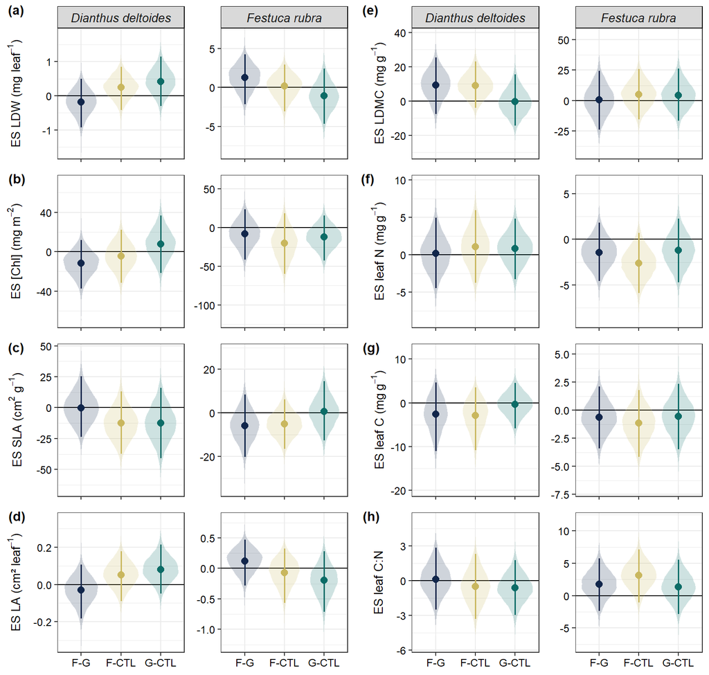

```r
es_ldw<-bootstrap_ES(response="LDW", data=data, n_perm=10000, plot=FALSE)
es_chl50<-bootstrap_ES(response="Chl50", data=data, n_perm=10000, plot=FALSE)
es_sla<-bootstrap_ES(response="SLA", data=data, n_perm=10000, plot=FALSE)
es_la<-bootstrap_ES(response="LA", data=data, n_perm=10000, plot=FALSE)
es_ldmc<-bootstrap_ES(response="LDMC", data=data, n_perm=10000, plot=FALSE)
es_nleaf<-bootstrap_ES(response="Nleaf", data=data, n_perm=10000, plot=FALSE)
es_cleaf<-bootstrap_ES(response="Cleaf", data=data, n_perm=10000, plot=FALSE)
es_cnleaf<-bootstrap_ES(response="CNleaf", data=data, n_perm=10000, plot=FALSE)

cex.axis<-9
cex.title<-10
cex.pt<-1.5
cex.mean<-2.5

cbPalette <- c("#11264B", "#C9B75E", "#0C6C67")

#LDW

p1<-ggplot(data)+
  facet_wrap(~Species, scales="free_y")+
  geom_hline(yintercept=0)+
  stat_ydensity(data=es_ldw$bootstrap, aes(x=Contrast, y=ES, fill=Contrast),
                color=adjustcolor("white", alpha.f = 0.1), alpha=0.2, inherit.aes = FALSE)+
  geom_segment(data=es_ldw$summary, aes(x=Contrast, xend=Contrast, y=lowCI, yend=highCI, color=Contrast),
               size=0.6, inherit.aes = F)+
  geom_point(data=es_ldw$summary, mapping=aes(x=Contrast, y=ES, color=Contrast, fill=Contrast),
             shape=21, size=cex.mean, inherit.aes = F)+
  theme_bw()+
  xlab("")+
  ylab(expression(paste("ES LDW (mg ", leaf^-1, ")", sep="")))+
  theme(axis.title=element_text(size=cex.title, color="black", face="plain"),
        axis.title.y=element_text(margin = margin(t = 0, r = 5, b = 0, l = 0)),
        axis.title.x=element_blank(),
        axis.text=element_text(size=cex.axis, color="black"),
        axis.text.x = element_blank(),
        legend.position = "none",
        strip.text = element_text(size=10, face="italic"),
        strip.background=element_rect(color="black"))+
  scale_fill_manual(values=cbPalette)+
  scale_color_manual(values=cbPalette)

#Chl50

p2<-ggplot(data)+
  facet_wrap(~Species, scales="free_y")+
  geom_hline(yintercept=0)+
  stat_ydensity(data=es_chl50$bootstrap, aes(x=Contrast, y=ES, fill=Contrast),
                color=adjustcolor("white", alpha.f = 0.1), alpha=0.2, inherit.aes = FALSE)+
  geom_segment(data=es_chl50$summary, aes(x=Contrast, xend=Contrast, y=lowCI, yend=highCI, color=Contrast),
               size=0.6, inherit.aes = F)+
  geom_point(data=es_chl50$summary, mapping=aes(x=Contrast, y=ES, color=Contrast, fill=Contrast),
             shape=21, size=cex.mean, inherit.aes = F)+
  theme_bw()+
  xlab("")+
  ylab(expression(paste("ES [Chl] (mg ", m^-2, ")", sep="")))+
  theme(axis.title=element_text(size=cex.title, color="black", face="plain"),
        axis.title.y=element_text(margin = margin(t = 0, r = 5, b = 0, l = 0)),
        axis.title.x=element_blank(),
        axis.text=element_text(size=cex.axis, color="black"),
        axis.text.x = element_blank(),
        legend.position = "none",
        strip.text = element_blank(),
        strip.background=element_blank())+
  scale_fill_manual(values=cbPalette)+
  scale_color_manual(values=cbPalette)

#SLA

p3<-ggplot(data)+
  facet_wrap(~Species, scales="free_y")+
  geom_hline(yintercept = 0)+
  stat_ydensity(data=es_sla$bootstrap, aes(x=Contrast, y=ES, fill=Contrast),
                color=adjustcolor("white", alpha.f = 0.1), alpha=0.2, inherit.aes = FALSE)+
  geom_segment(data=es_sla$summary, aes(x=Contrast, xend=Contrast, y=lowCI, yend=highCI, color=Contrast),
               size=0.6, inherit.aes = F)+
  geom_point(data=es_sla$summary, mapping=aes(x=Contrast, y=ES, color=Contrast, fill=Contrast),
             shape=21, size=cex.mean, inherit.aes = F)+
  theme_bw()+
  xlab("")+
  ylab(expression(paste("ES SLA (", cm^2, " ", g^-1, ")", sep="")))+
  theme(axis.title=element_text(size=cex.title, color="black", face="plain"),
        axis.title.y=element_text(vjust=0.5, margin = margin(t = 0, r = 5, b = 0, l = 0)),
        axis.title.x=element_blank(),
        axis.text=element_text(size=cex.axis, color="black"),
        axis.text.x = element_blank(),
        legend.position = "none",
        strip.text = element_blank(),
        strip.background=element_blank())+
  scale_fill_manual(values=cbPalette)+
  scale_color_manual(values=cbPalette)

#LA

p4<-ggplot(data)+
  facet_wrap(~Species, scales="free_y")+
  geom_hline(yintercept=0)+
  stat_ydensity(data=es_la$bootstrap, aes(x=Contrast, y=ES, fill=Contrast),
                color=adjustcolor("white", alpha.f = 0.1), alpha=0.2, inherit.aes = FALSE)+
  geom_segment(data=es_la$summary, aes(x=Contrast, xend=Contrast, y=lowCI, yend=highCI, color=Contrast),
               size=0.6, inherit.aes = F)+
  geom_point(data=es_la$summary, mapping=aes(x=Contrast, y=ES, color=Contrast, fill=Contrast),
             shape=21, size=cex.mean, inherit.aes = F)+
  theme_bw()+
  xlab("")+
  ylab(expression(paste("ES LA (cm² ", leaf^-1, ")", sep="")))+
  theme(axis.title=element_text(size=cex.title, color="black", face="plain"),
        axis.title.y=element_text(margin = margin(t = 0, r = 5, b = 0, l = 0)),
        axis.title.x=element_blank(),
        axis.text=element_text(size=cex.axis, color="black"),
        legend.position = "none",
        strip.text = element_blank(),
        strip.background=element_blank())+
  scale_x_discrete(limits=c("Forbs-Grasses", "Forbs-Soil", "Grasses-Soil"),
                   labels=c("F-G", "F-CTL", "G-CTL"))+
  scale_fill_manual(values=cbPalette)+
  scale_color_manual(values=cbPalette)

#LDMC

p5<-ggplot(data)+
  facet_wrap(~Species, scales="free_y")+
  geom_hline(yintercept = 0)+
  stat_ydensity(data=es_ldmc$bootstrap, aes(x=Contrast, y=ES, fill=Contrast),
                color=adjustcolor("white", alpha.f = 0.1), alpha=0.2, inherit.aes = FALSE)+
  geom_segment(data=es_ldmc$summary, aes(x=Contrast, xend=Contrast, y=lowCI, yend=highCI, color=Contrast),
               size=0.6, inherit.aes = F)+
  geom_point(data=es_ldmc$summary, mapping=aes(x=Contrast, y=ES, color=Contrast, fill=Contrast),
             shape=21, size=cex.mean, inherit.aes = F)+
  theme_bw()+
  xlab("")+
  ylab(expression(paste("ES LDMC (mg ", g^-1, ")", sep="")))+
  theme(axis.title=element_text(size=cex.title, color="black", face="plain"),
        axis.title.y=element_text(margin = margin(t = 0, r = -10, b = 0, l = 0)),
        axis.title.x=element_blank(),
        axis.text=element_text(size=cex.axis, color="black"),
        axis.text.x = element_blank(),
        legend.position = "none",
        strip.text = element_text(size=10, face="italic"),
        strip.background=element_rect(color="black"))+
  scale_fill_manual(values=cbPalette)+
  scale_color_manual(values=cbPalette)

#Nleaf

p6<-ggplot(data)+
  facet_wrap(~Species, scales="free_y")+
  geom_hline(yintercept = 0)+
  stat_ydensity(data=es_nleaf$bootstrap, aes(x=Contrast, y=ES, fill=Contrast),
                color=adjustcolor("white", alpha.f = 0.1), alpha=0.2, inherit.aes = FALSE)+
  geom_segment(data=es_nleaf$summary, aes(x=Contrast, xend=Contrast, y=lowCI, yend=highCI, color=Contrast),
               size=0.6, inherit.aes = F)+
  geom_point(data=es_nleaf$summary, mapping=aes(x=Contrast, y=ES, color=Contrast, fill=Contrast),
             shape=21, size=cex.mean, inherit.aes = F)+
  theme_bw()+
  xlab("")+
  ylab(expression(paste("ES leaf N (mg ", g^-1, ")", sep="")))+
  theme(axis.title=element_text(size=cex.title, color="black", face="plain"),
        axis.title.y=element_text(margin = margin(t = 0, r = -10, b = 0, l = 0)),
        axis.title.x=element_blank(),
        axis.text=element_text(size=cex.axis, color="black"),
        axis.text.x = element_blank(),
        legend.position = "none",
        strip.text = element_blank(),
        strip.background=element_blank())+
  scale_fill_manual(values=cbPalette)+
  scale_color_manual(values=cbPalette)

#Cleaf

p7<-ggplot(data)+
  facet_wrap(~Species, scales="free_y")+
  geom_hline(yintercept = 0)+
  stat_ydensity(data=es_cleaf$bootstrap, aes(x=Contrast, y=ES, fill=Contrast),
                color=adjustcolor("white", alpha.f = 0.1), alpha=0.2, inherit.aes = FALSE)+
  geom_segment(data=es_cleaf$summary, aes(x=Contrast, xend=Contrast, y=lowCI, yend=highCI, color=Contrast),
               size=0.6, inherit.aes = F)+
  geom_point(data=es_cleaf$summary, mapping=aes(x=Contrast, y=ES, color=Contrast, fill=Contrast),
             shape=21, size=cex.mean, inherit.aes = F)+
  theme_bw()+
  xlab("")+
  ylab(expression(paste("ES leaf C (mg ", g^-1, ")", sep="")))+
  theme(axis.title=element_text(size=cex.title, color="black", face="plain"),
        axis.title.y=element_text(margin = margin(t = 0, r = -10, b = 0, l = 0)),
        axis.title.x=element_blank(),
        axis.text=element_text(size=cex.axis, color="black"),
        axis.text.x = element_blank(),
        legend.position = "none",
        strip.text = element_blank(),
        strip.background=element_blank())+
  scale_fill_manual(values=cbPalette)+
  scale_color_manual(values=cbPalette)

#CN ratio

p8<-ggplot(data)+
  facet_wrap(~Species, scales="free_y")+
  geom_hline(yintercept = 0)+
  stat_ydensity(data=es_cnleaf$bootstrap, aes(x=Contrast, y=ES, fill=Contrast),
                color=adjustcolor("white", alpha.f = 0.1), alpha=0.2, inherit.aes = FALSE)+
  geom_segment(data=es_cnleaf$summary, aes(x=Contrast, xend=Contrast, y=lowCI, yend=highCI, color=Contrast),
               size=0.6, inherit.aes = F)+
  geom_point(data=es_cnleaf$summary, mapping=aes(x=Contrast, y=ES, color=Contrast, fill=Contrast),
             shape=21, size=cex.mean, inherit.aes = F)+
  theme_bw()+
  xlab("")+
  ylab("ES leaf C:N")+
  theme(axis.title=element_text(size=cex.title, color="black", face="plain"),
        axis.title.y=element_text(margin = margin(t = 0, r = -10, b = 0, l = 0)),
        axis.title.x=element_blank(),
        axis.text=element_text(size=cex.axis, color="black"),
        legend.position = "none",
        strip.text = element_blank(),
        strip.background=element_blank())+
  scale_x_discrete(limits=c("Forbs-Grasses", "Forbs-Soil", "Grasses-Soil"),
                   labels=c("F-G", "F-CTL", "G-CTL"))+
  scale_fill_manual(values=cbPalette)+
  scale_color_manual(values=cbPalette)

p9<-ggarrange(p1,p5,p2,p6,p3,p7,p4,p8, nrow=4, ncol=2, align="v",
              labels=c("(a)", "(e)", "(b)", "(f)", "(c)", "(g)", "(d)", "(h)"),
              font.label = list(size=11))

p9
```

```r
#ggsave("Leaf_traits_ES.tiff", p9, dpi=1000, compression="lzw", width=21, height=20, units="cm")
```

# Root functional traits

## Plot results

```r
stat_rld<-bootstrap_mean(response="RLD", data=data, n_perm=10000)
knitr::kable(stat_rld, caption="Results for root length density (mean in cm/cm³, ES in %)")
```

Results for root length density (mean in cm/cm³, ES in %)

| Species | Treatment | lowCI | mean | highCI | ES |
| --- | --- | --- | --- | --- | --- |
| Dianthus deltoides | Forbs | 2.041389 | 2.380743 | 2.777985 | -34.169311 |
| Dianthus deltoides | Grasses | 2.674661 | 3.034035 | 3.437193 | -16.104899 |
| Dianthus deltoides | Soil | 3.315315 | 3.616463 | 3.886834 | 0.000000 |
| Festuca rubra | Forbs | 5.442426 | 7.105711 | 9.199804 | -4.069103 |
| Festuca rubra | Grasses | 6.703470 | 7.964899 | 9.260197 | 7.530399 |
| Festuca rubra | Soil | 6.691578 | 7.407114 | 8.148540 | 0.000000 |

```r
stat_rsd<-bootstrap_mean(response="RSD", data=data, n_perm=10000)
knitr::kable(stat_rsd, caption="Results for root surface density (mean in cm²/cm³, ES in %)")
```

Results for root surface density (mean in cm²/cm³, ES in %)

| Species | Treatment | lowCI | mean | highCI | ES |
| --- | --- | --- | --- | --- | --- |
| Dianthus deltoides | Forbs | 0.1049589 | 0.1224863 | 0.1414894 | -32.662575 |
| Dianthus deltoides | Grasses | 0.1349411 | 0.1522464 | 0.1709672 | -16.301829 |
| Dianthus deltoides | Soil | 0.1654580 | 0.1818993 | 0.1971323 | 0.000000 |
| Festuca rubra | Forbs | 0.2372485 | 0.2956855 | 0.3699269 | -2.653427 |
| Festuca rubra | Grasses | 0.2681129 | 0.3176215 | 0.3656232 | 4.568438 |
| Festuca rubra | Soil | 0.2769549 | 0.3037451 | 0.3323931 | 0.000000 |

```r
stat_srl<-bootstrap_mean(response="SRL", data=data, n_perm=10000)
knitr::kable(stat_srl, caption="Results for specific root length (mean in m/g, ES in %)")
```

Results for specific root length (mean in m/g, ES in %)

| Species | Treatment | lowCI | mean | highCI | ES |
| --- | --- | --- | --- | --- | --- |
| Dianthus deltoides | Forbs | 555.5740 | 636.0145 | 705.9211 | -10.015841 |
| Dianthus deltoides | Grasses | 564.8275 | 618.2581 | 664.9017 | -12.528040 |
| Dianthus deltoides | Soil | 680.9713 | 706.8072 | 735.1824 | 0.000000 |
| Festuca rubra | Forbs | 641.7898 | 730.9549 | 827.9540 | -6.214205 |
| Festuca rubra | Grasses | 741.4453 | 817.0565 | 889.6584 | 4.833133 |
| Festuca rubra | Soil | 685.6362 | 779.3877 | 860.2235 | 0.000000 |

```r
stat_sra<-bootstrap_mean(response="SRA", data=data, n_perm=10000)
knitr::kable(stat_sra, caption="Results for specific root area (mean in m²/g, ES in %)")
```

Results for specific root area (mean in m²/g, ES in %)

| Species | Treatment | lowCI | mean | highCI | ES |
| --- | --- | --- | --- | --- | --- |
| Dianthus deltoides | Forbs | 0.2918687 | 0.3250124 | 0.3517209 | -8.431005 |
| Dianthus deltoides | Grasses | 0.2902081 | 0.3095840 | 0.3258557 | -12.777825 |
| Dianthus deltoides | Soil | 0.3397385 | 0.3549372 | 0.3684163 | 0.000000 |
| Festuca rubra | Forbs | 0.2800813 | 0.3073682 | 0.3357335 | -3.355914 |
| Festuca rubra | Grasses | 0.3008616 | 0.3243360 | 0.3438987 | 1.979192 |
| Festuca rubra | Soil | 0.2868081 | 0.3180414 | 0.3471380 | 0.000000 |

```r
stat_rtd<-bootstrap_mean(response="RTD", data=data, n_perm=10000)
knitr::kable(stat_rtd, caption="Results for root tissue density (mean in mg/cm³, ES in %)")
```

Results for root tissue density (mean in mg/cm³, ES in %)

| Species | Treatment | lowCI | mean | highCI | ES |
| --- | --- | --- | --- | --- | --- |
| Dianthus deltoides | Forbs | 54.88487 | 58.99075 | 63.59159 | 3.684286 |
| Dianthus deltoides | Grasses | 59.72131 | 61.27275 | 62.91814 | 7.695227 |
| Dianthus deltoides | Soil | 52.63141 | 56.89459 | 61.41086 | 0.000000 |
| Festuca rubra | Forbs | 72.95428 | 78.22501 | 83.37369 | -6.057074 |
| Festuca rubra | Grasses | 78.58888 | 84.20715 | 89.44343 | 1.127061 |
| Festuca rubra | Soil | 75.87312 | 83.26866 | 90.00739 | 0.000000 |

```r
stat_d<-bootstrap_mean(response="D", data=data, n_perm=10000)
knitr::kable(stat_d, caption="Results for root diameter (mean in mm, ES in %)")
```

Results for root diameter (mean in mm, ES in %)

| Species | Treatment | lowCI | mean | highCI | ES |
| --- | --- | --- | --- | --- | --- |
| Dianthus deltoides | Forbs | 0.1569374 | 0.1642400 | 0.1708633 | 2.5314984 |
| Dianthus deltoides | Grasses | 0.1545765 | 0.1603464 | 0.1655036 | 0.1008066 |
| Dianthus deltoides | Soil | 0.1529264 | 0.1601849 | 0.1676786 | 0.0000000 |
| Festuca rubra | Forbs | 0.1282410 | 0.1357616 | 0.1444304 | 3.5565424 |
| Festuca rubra | Grasses | 0.1223586 | 0.1272369 | 0.1324055 | -2.9459288 |
| Festuca rubra | Soil | 0.1251954 | 0.1310990 | 0.1374372 | 0.0000000 |

```r
stat_nroot<-bootstrap_mean(response="Nroot", data=data, n_perm=10000)
knitr::kable(stat_nroot, caption="Results for root N concentration (mean in mg/g, ES in %)")
```

Results for root N concentration (mean in mg/g, ES in %)

| Species | Treatment | lowCI | mean | highCI | ES |
| --- | --- | --- | --- | --- | --- |
| Dianthus deltoides | Forbs | 11.801533 | 13.636763 | 15.789606 | 7.7910190 |
| Dianthus deltoides | Grasses | 11.129777 | 12.461624 | 14.114220 | -1.4977950 |
| Dianthus deltoides | Soil | 11.247666 | 12.651112 | 13.972590 | 0.0000000 |
| Festuca rubra | Forbs | 8.590649 | 8.953410 | 9.359641 | -0.1408871 |
| Festuca rubra | Grasses | 8.841416 | 9.238236 | 9.641509 | 3.0358323 |
| Festuca rubra | Soil | 8.419019 | 8.966042 | 9.566679 | 0.0000000 |

```r
stat_croot<-bootstrap_mean(response="Croot", data=data, n_perm=10000)
knitr::kable(stat_croot, caption="Results for root C concentration (mean in mg/g, ES in %)")
```

Results for root C concentration (mean in mg/g, ES in %)

| Species | Treatment | lowCI | mean | highCI | ES |
| --- | --- | --- | --- | --- | --- |
| Dianthus deltoides | Forbs | 462.9429 | 465.5345 | 468.4756 | 0.3098832 |
| Dianthus deltoides | Grasses | 462.7230 | 464.7099 | 466.4797 | 0.1322008 |
| Dianthus deltoides | Soil | 462.3752 | 464.0963 | 465.7682 | 0.0000000 |
| Festuca rubra | Forbs | 467.8124 | 470.4338 | 472.9067 | -0.4976844 |
| Festuca rubra | Grasses | 469.5990 | 472.1566 | 474.2205 | -0.1332872 |
| Festuca rubra | Soil | 471.7586 | 472.7868 | 473.8420 | 0.0000000 |

```r
stat_cnroot<-bootstrap_mean(response="CNroot", data=data, n_perm=10000)
knitr::kable(stat_cnroot, caption="Results for root C:N (ES in %)")
```

Results for root C:N (ES in %)

| Species | Treatment | lowCI | mean | highCI | ES |
| --- | --- | --- | --- | --- | --- |
| Dianthus deltoides | Forbs | 31.03892 | 35.65543 | 39.93980 | -5.7954630 |
| Dianthus deltoides | Grasses | 34.36056 | 38.48161 | 42.33887 | 1.6715459 |
| Dianthus deltoides | Soil | 33.72709 | 37.84895 | 43.12440 | 0.0000000 |
| Festuca rubra | Forbs | 50.35509 | 52.81637 | 55.10820 | -0.8394645 |
| Festuca rubra | Grasses | 49.23987 | 51.34144 | 53.48284 | -3.6085770 |
| Festuca rubra | Soil | 49.97681 | 53.26350 | 56.38851 | 0.0000000 |

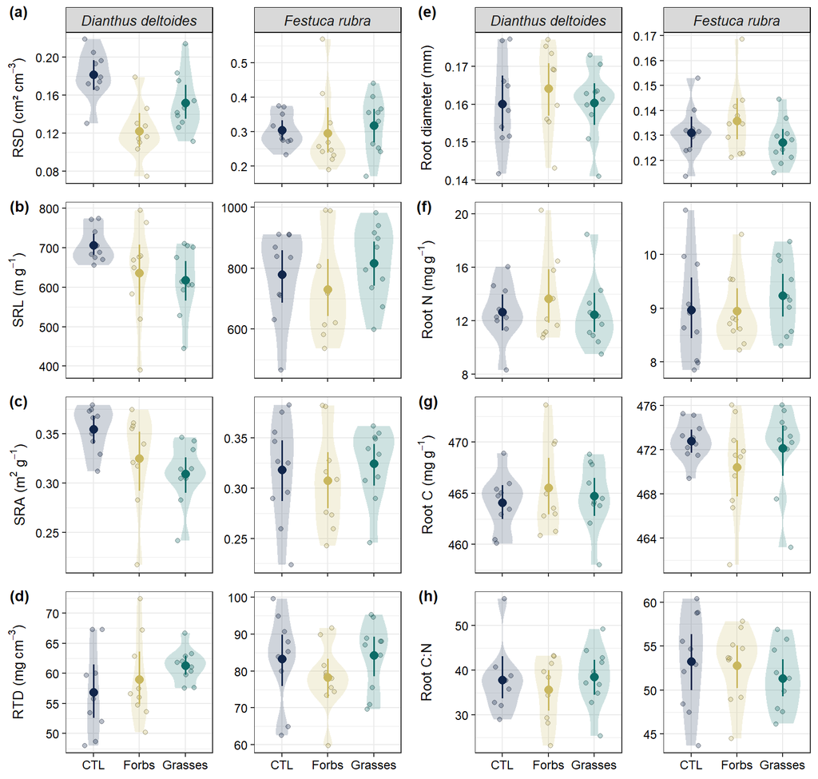

```r
cex.axis<-9
cex.title<-10
cex.pt<-1.5

cbPalette <- c("#C9B75E", "#0C6C67", "#11264B")

#RSD: root surface density

p1<-ggplot(data, aes(x=Treatment, y=RSD, fill=Treatment))+
  facet_wrap(~Species, scales="free_y")+
  stat_ydensity(color=adjustcolor("white", alpha.f = 0.1), alpha=0.2)+
  geom_jitter(aes(x=Treatment, y=RSD, fill=Treatment), shape=21, size=cex.pt, alpha=0.3,
              position=position_jitter(width=0.2))+
  stat_summary(aes(x=Treatment, y=RSD, color=Treatment),
               fun.data="mean_cl_boot", fun.args = list(B=10000), size=0.6, shape=16)+
  theme_bw()+
  xlab("")+
  ylab(expression(paste("RSD (cm² ", cm^-3, ")", sep="")))+
  theme(axis.title=element_text(size=cex.title, color="black", face="plain"),
        axis.title.y=element_text(margin = margin(t = 0, r = 5, b = 0, l = 0)),
        axis.title.x=element_blank(),
        axis.text=element_text(size=cex.axis, color="black"),
        axis.text.x = element_blank(),
        legend.position = "none",
        strip.text = element_text(size=10, face="italic"),
        strip.background=element_rect(color="black"))+
  scale_x_discrete(limits=c("Soil", "Forbs", "Grasses"),
                   labels=c("CTL", "Forbs", "Grasses"))+
  scale_fill_manual(values=cbPalette)+
  scale_color_manual(values=cbPalette)

#SRL: specific root length

p2<-ggplot(data, aes(x=Treatment, y=SRL, fill=Treatment))+
  facet_wrap(~Species, scales="free_y")+
  stat_ydensity(color=adjustcolor("white", alpha.f = 0.1), alpha=0.2)+
  geom_jitter(aes(x=Treatment, y=SRL, fill=Treatment), shape=21, size=cex.pt, alpha=0.3,
              position=position_jitter(width=0.2))+
  stat_summary(aes(x=Treatment, y=SRL, color=Treatment),
               fun.data="mean_cl_boot", fun.args = list(B=10000), size=0.6, shape=16)+
  theme_bw()+
  xlab("")+
  ylab(expression(paste("SRL (m ", g^-1, ")", sep="")))+
  theme(axis.title=element_text(size=cex.title, color="black", face="plain"),
        axis.title.y=element_text(margin = margin(t = 0, r = 5, b = 0, l = 0)),
        axis.title.x=element_blank(),
        axis.text=element_text(size=cex.axis, color="black"),
        axis.text.x = element_blank(),
        legend.position = "none",
        strip.text = element_blank(),
        strip.background=element_blank())+
  scale_x_discrete(limits=c("Soil", "Forbs", "Grasses"),
                   labels=c("CTL", "Forbs", "Grasses"))+
  scale_fill_manual(values=cbPalette)+
  scale_color_manual(values=cbPalette)

#SRA: specific root surface area

p3<-ggplot(data, aes(x=Treatment, y=SRA, fill=Treatment))+
  facet_wrap(~Species, scales="free_y")+
  stat_ydensity(color=adjustcolor("white", alpha.f = 0.1), alpha=0.2)+
  geom_jitter(aes(x=Treatment, y=SRA, fill=Treatment), shape=21, size=cex.pt, alpha=0.3,
              position=position_jitter(width=0.2))+
  stat_summary(aes(x=Treatment, y=SRA, color=Treatment),
               fun.data="mean_cl_boot", fun.args = list(B=10000), size=0.6, shape=16)+
  theme_bw()+
  xlab("")+
  ylab(expression(paste("SRA (", m^2, " ", g^-1, ")", sep="")))+
  theme(axis.title=element_text(size=cex.title, color="black", face="plain"),
        axis.title.y=element_text(vjust=0.5, margin = margin(t = 0, r = 5, b = 0, l = 0)),
        axis.title.x=element_blank(),
        axis.text=element_text(size=cex.axis, color="black"),
        axis.text.x = element_blank(),
        legend.position = "none",
        strip.text = element_blank(),
        strip.background=element_blank())+
  scale_x_discrete(limits=c("Soil", "Forbs", "Grasses"),
                   labels=c("CTL", "Forbs", "Grasses"))+
  scale_fill_manual(values=cbPalette)+
  scale_color_manual(values=cbPalette)

#RTD: root tissue density

p4<-ggplot(data, aes(x=Treatment, y=RTD, fill=Treatment))+
  facet_wrap(~Species, scales="free_y")+
  stat_ydensity(color=adjustcolor("white", alpha.f = 0.1), alpha=0.2)+
  geom_jitter(aes(x=Treatment, y=RTD, fill=Treatment), shape=21, size=cex.pt, alpha=0.3,
              position=position_jitter(width=0.2))+
  stat_summary(aes(x=Treatment, y=RTD, color=Treatment),
               fun.data="mean_cl_boot", fun.args = list(B=10000), size=0.6, shape=16)+
  theme_bw()+
  xlab("")+
  ylab(expression(paste("RTD (mg ", cm^-3, ")", sep="")))+
  theme(axis.title=element_text(size=cex.title, color="black", face="plain"),
        axis.title.y=element_text(margin = margin(t = 0, r = 5, b = 0, l = 0)),
        axis.title.x=element_blank(),
        axis.text=element_text(size=cex.axis, color="black"),
        legend.position = "none",
        strip.text = element_blank(),
        strip.background=element_blank())+
  scale_x_discrete(limits=c("Soil", "Forbs", "Grasses"),
                   labels=c("CTL", "Forbs", "Grasses"))+
  scale_fill_manual(values=cbPalette)+
  scale_color_manual(values=cbPalette)

#D: length-weighted average root diameter

p5<-ggplot(data, aes(x=Treatment, y=D, fill=Treatment))+
  facet_wrap(~Species, scales="free_y")+
  stat_ydensity(color=adjustcolor("white", alpha.f = 0.1), alpha=0.2)+
  geom_jitter(aes(x=Treatment, y=D, fill=Treatment), shape=21, size=cex.pt, alpha=0.3,
              position=position_jitter(width=0.2))+
  stat_summary(aes(x=Treatment, y=D, color=Treatment),
               fun.data="mean_cl_boot", fun.args = list(B=10000), size=0.6, shape=16)+
  theme_bw()+
  xlab("")+
  ylab("Root diameter (mm)")+
  theme(axis.title=element_text(size=cex.title, color="black", face="plain"),
        axis.title.y=element_text(margin = margin(t = 0, r = 5, b = 0, l = 0)),
        axis.title.x=element_blank(),
        axis.text=element_text(size=cex.axis, color="black"),
        axis.text.x = element_blank(),
        legend.position = "none",
        strip.text = element_text(size=10, face="italic"),
        strip.background=element_rect(color="black"))+
  scale_x_discrete(limits=c("Soil", "Forbs", "Grasses"),
                   labels=c("CTL", "Forbs", "Grasses"))+
  scale_fill_manual(values=cbPalette)+
  scale_color_manual(values=cbPalette)

#Nroot: root nitrogen content

p6<-ggplot(data, aes(x=Treatment, y=Nroot, fill=Treatment))+
  facet_wrap(~Species, scales="free_y")+
  stat_ydensity(color=adjustcolor("white", alpha.f = 0.1), alpha=0.2)+
  geom_jitter(aes(x=Treatment, y=Nroot, fill=Treatment), shape=21, size=cex.pt, alpha=0.3,
              position=position_jitter(width=0.2))+
  stat_summary(aes(x=Treatment, y=Nroot, color=Treatment),
               fun.data="mean_cl_boot", fun.args = list(B=10000), size=0.6, shape=16)+
  theme_bw()+
  xlab("")+
  ylab(expression(paste("Root N (mg ", g^-1, ")", sep="")))+
  theme(axis.title=element_text(size=cex.title, color="black", face="plain"),
        axis.title.y=element_text(margin = margin(t = 0, r = 5, b = 0, l = 0)),
        axis.title.x=element_blank(),
        axis.text=element_text(size=cex.axis, color="black"),
        axis.text.x = element_blank(),
        legend.position = "none",
        strip.text = element_blank(),
        strip.background=element_blank())+
  scale_x_discrete(limits=c("Soil", "Forbs", "Grasses"),
                   labels=c("CTL", "Forbs", "Grasses"))+
  scale_fill_manual(values=cbPalette)+
  scale_color_manual(values=cbPalette)

#Croot: root carbon content

p7<-ggplot(data, aes(x=Treatment, y=Croot, fill=Treatment))+
  facet_wrap(~Species, scales="free_y")+
  stat_ydensity(color=adjustcolor("white", alpha.f = 0.1), alpha=0.2)+
  geom_jitter(aes(x=Treatment, y=Croot, fill=Treatment), shape=21, size=cex.pt, alpha=0.3,
              position=position_jitter(width=0.2))+
  stat_summary(aes(x=Treatment, y=Croot, color=Treatment),
               fun.data="mean_cl_boot", fun.args = list(B=10000), size=0.6, shape=16)+
  theme_bw()+
  xlab("")+
  ylab(expression(paste("Root C (mg ", g^-1, ")", sep="")))+
  theme(axis.title=element_text(size=cex.title, color="black", face="plain"),
        axis.title.y=element_text(margin = margin(t = 0, r = 5, b = 0, l = 0)),
        axis.title.x=element_blank(),
        axis.text=element_text(size=cex.axis, color="black"),
        axis.text.x = element_blank(),
        legend.position = "none",
        strip.text = element_blank(),
        strip.background=element_blank())+
  scale_x_discrete(limits=c("Soil", "Forbs", "Grasses"),
                   labels=c("CTL", "Forbs", "Grasses"))+
  scale_fill_manual(values=cbPalette)+
  scale_color_manual(values=cbPalette)

#CNroot: root C:N

p8<-ggplot(data, aes(x=Treatment, y=CNroot, fill=Treatment))+
  facet_wrap(~Species, scales="free_y")+
  stat_ydensity(color=adjustcolor("white", alpha.f = 0.1), alpha=0.2)+
  geom_jitter(aes(x=Treatment, y=CNroot, fill=Treatment), shape=21, size=cex.pt, alpha=0.3,
              position=position_jitter(width=0.2))+
  stat_summary(aes(x=Treatment, y=CNroot, color=Treatment),
               fun.data="mean_cl_boot", fun.args = list(B=10000), size=0.6, shape=16)+
  theme_bw()+
  xlab("")+
  ylab("Root C:N")+
  theme(axis.title=element_text(size=cex.title, color="black", face="plain"),
        axis.title.y=element_text(margin = margin(t = 0, r = 5, b = 0, l = 0)),
        axis.title.x=element_blank(),
        axis.text=element_text(size=cex.axis, color="black"),
        legend.position = "none",
        strip.text = element_blank(),
        strip.background=element_blank())+
  scale_x_discrete(limits=c("Soil", "Forbs", "Grasses"),
                   labels=c("CTL", "Forbs", "Grasses"))+
  scale_fill_manual(values=cbPalette)+
  scale_color_manual(values=cbPalette)

p9<-ggarrange(p1,p5,p2,p6,p3,p7,p4,p8, nrow=4, ncol=2, align="v",
              labels=c("(a)", "(e)", "(b)", "(f)", "(c)", "(g)", "(d)", "(h)"),
              font.label = list(size=11))

p9
```

```r
#ggsave("Root_traits.tiff", p9, dpi=1000, compression="lzw", width=21, height=20, units="cm")
```

## Plot unstandardised effect sizes

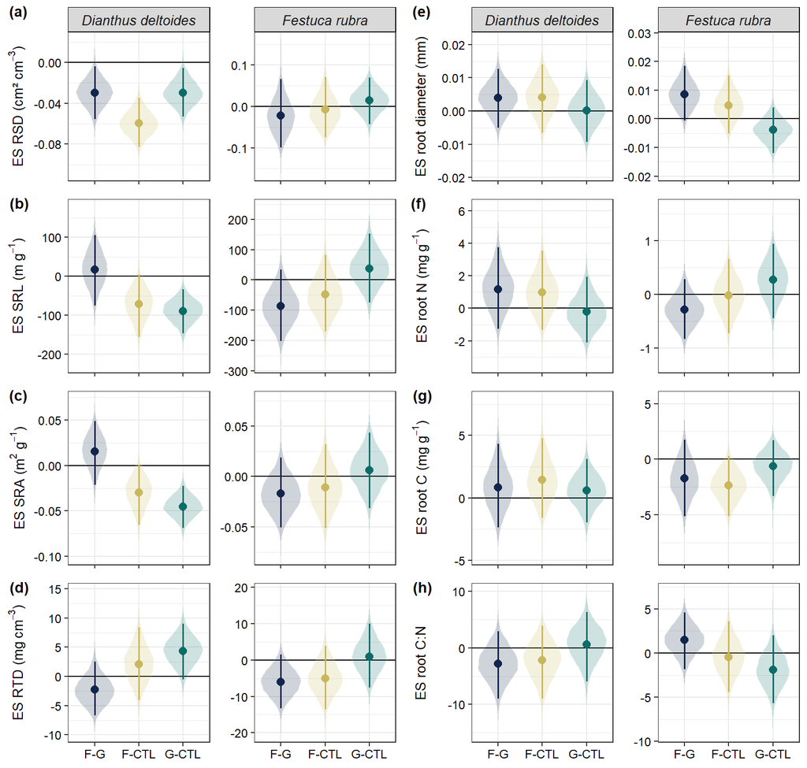

```r
es_rld<-bootstrap_ES(response="RLD", data=data, n_perm=10000, plot=FALSE)
es_rsd<-bootstrap_ES(response="RSD", data=data, n_perm=10000, plot=FALSE)
es_srl<-bootstrap_ES(response="SRL", data=data, n_perm=10000, plot=FALSE)
es_sra<-bootstrap_ES(response="SRA", data=data, n_perm=10000, plot=FALSE)
es_rtd<-bootstrap_ES(response="RTD", data=data, n_perm=10000, plot=FALSE)
es_d<-bootstrap_ES(response="D", data=data, n_perm=10000, plot=FALSE)
es_nroot<-bootstrap_ES(response="Nroot", data=data, n_perm=10000, plot=FALSE)
es_croot<-bootstrap_ES(response="Croot", data=data, n_perm=10000, plot=FALSE)
es_cnroot<-bootstrap_ES(response="CNroot", data=data, n_perm=10000, plot=FALSE)

cex.axis<-9
cex.title<-10
cex.pt<-1.5
cex.mean<-2.5

cbPalette <- c("#11264B", "#C9B75E", "#0C6C67")

#RSD: root surface density

p1<-ggplot(data)+
  facet_wrap(~Species, scales="free_y")+
  geom_hline(yintercept=0)+
  stat_ydensity(data=es_rsd$bootstrap, aes(x=Contrast, y=ES, fill=Contrast),
                color=adjustcolor("white", alpha.f = 0.1), alpha=0.2, inherit.aes = FALSE)+
  geom_segment(data=es_rsd$summary, aes(x=Contrast, xend=Contrast, y=lowCI, yend=highCI, color=Contrast),
               size=0.6, inherit.aes = F)+
  geom_point(data=es_rsd$summary, mapping=aes(x=Contrast, y=ES, color=Contrast, fill=Contrast),
             shape=21, size=cex.mean, inherit.aes = F)+
  theme_bw()+
  xlab("")+
  ylab(expression(paste("ES RSD (cm² ", cm^-3, ")", sep="")))+
  theme(axis.title=element_text(size=cex.title, color="black", face="plain"),
        axis.title.y=element_text(margin = margin(t = 0, r = 2, b = 0, l = 0)),
        axis.title.x=element_blank(),
        axis.text=element_text(size=cex.axis, color="black"),
        axis.text.x = element_blank(),
        legend.position = "none",
        strip.text = element_text(size=10, face="italic"),
        strip.background=element_rect(color="black"))+
  scale_fill_manual(values=cbPalette)+
  scale_color_manual(values=cbPalette)

#SRL: specific root length

p2<-ggplot(data)+
  facet_wrap(~Species, scales="free_y")+
  geom_hline(yintercept=0)+
  stat_ydensity(data=es_srl$bootstrap, aes(x=Contrast, y=ES, fill=Contrast),
                color=adjustcolor("white", alpha.f = 0.1), alpha=0.2, inherit.aes = FALSE)+
  geom_segment(data=es_srl$summary, aes(x=Contrast, xend=Contrast, y=lowCI, yend=highCI, color=Contrast),
               size=0.6, inherit.aes = F)+
  geom_point(data=es_srl$summary, mapping=aes(x=Contrast, y=ES, color=Contrast, fill=Contrast),
             shape=21, size=cex.mean, inherit.aes = F)+
  theme_bw()+
  xlab("")+
  ylab(expression(paste("ES SRL (m ", g^-1, ")", sep="")))+
  theme(axis.title=element_text(size=cex.title, color="black", face="plain"),
        axis.title.y=element_text(margin = margin(t = 0, r = 2, b = 0, l = 0)),
        axis.title.x=element_blank(),
        axis.text=element_text(size=cex.axis, color="black"),
        axis.text.x = element_blank(),
        legend.position = "none",
        strip.text = element_blank(),
        strip.background=element_blank())+
  scale_fill_manual(values=cbPalette)+
  scale_color_manual(values=cbPalette)

#SRA: specific root surface area

p3<-ggplot(data)+
  facet_wrap(~Species, scales="free_y")+
  geom_hline(yintercept = 0)+
  stat_ydensity(data=es_sra$bootstrap, aes(x=Contrast, y=ES, fill=Contrast),
                color=adjustcolor("white", alpha.f = 0.1), alpha=0.2, inherit.aes = FALSE)+
  geom_segment(data=es_sra$summary, aes(x=Contrast, xend=Contrast, y=lowCI, yend=highCI, color=Contrast),
               size=0.6, inherit.aes = F)+
  geom_point(data=es_sra$summary, mapping=aes(x=Contrast, y=ES, color=Contrast, fill=Contrast),
             shape=21, size=cex.mean, inherit.aes = F)+
  theme_bw()+
  xlab("")+
  ylab(expression(paste("ES SRA (", m^2, " ", g^-1, ")", sep="")))+
  theme(axis.title=element_text(size=cex.title, color="black", face="plain"),
        axis.title.y=element_text(vjust=0.5, margin = margin(t = 0, r = 2, b = 0, l = 0)),
        axis.title.x=element_blank(),
        axis.text=element_text(size=cex.axis, color="black"),
        axis.text.x = element_blank(),
        legend.position = "none",
        strip.text = element_blank(),
        strip.background=element_blank())+
  scale_fill_manual(values=cbPalette)+
  scale_color_manual(values=cbPalette)

#RTD: root tissue density

p4<-ggplot(data)+
  facet_wrap(~Species, scales="free_y")+
  geom_hline(yintercept=0)+
  stat_ydensity(data=es_rtd$bootstrap, aes(x=Contrast, y=ES, fill=Contrast),
                color=adjustcolor("white", alpha.f = 0.1), alpha=0.2, inherit.aes = FALSE)+
  geom_segment(data=es_rtd$summary, aes(x=Contrast, xend=Contrast, y=lowCI, yend=highCI, color=Contrast),
               size=0.6, inherit.aes = F)+
  geom_point(data=es_rtd$summary, mapping=aes(x=Contrast, y=ES, color=Contrast, fill=Contrast),
             shape=21, size=cex.mean, inherit.aes = F)+
  theme_bw()+
  xlab("")+
  ylab(expression(paste("ES RTD (mg ", cm^-3, ")", sep="")))+
  theme(axis.title=element_text(size=cex.title, color="black", face="plain"),
        axis.title.y=element_text(margin = margin(t = 0, r = 2, b = 0, l = 0)),
        axis.title.x=element_blank(),
        axis.text=element_text(size=cex.axis, color="black"),
        legend.position = "none",
        strip.text = element_blank(),
        strip.background=element_blank())+
  scale_x_discrete(limits=c("Forbs-Grasses", "Forbs-Soil", "Grasses-Soil"),
                   labels=c("F-G", "F-CTL", "G-CTL"))+
  scale_fill_manual(values=cbPalette)+
  scale_color_manual(values=cbPalette)

#D: length-weighted average root diameter

p5<-ggplot(data)+
  facet_wrap(~Species, scales="free_y")+
  geom_hline(yintercept = 0)+
  stat_ydensity(data=es_d$bootstrap, aes(x=Contrast, y=ES, fill=Contrast),
                color=adjustcolor("white", alpha.f = 0.1), alpha=0.2, inherit.aes = FALSE)+
  geom_segment(data=es_d$summary, aes(x=Contrast, xend=Contrast, y=lowCI, yend=highCI, color=Contrast),
               size=0.6, inherit.aes = F)+
  geom_point(data=es_d$summary, mapping=aes(x=Contrast, y=ES, color=Contrast, fill=Contrast),
             shape=21, size=cex.mean, inherit.aes = F)+
  theme_bw()+
  xlab("")+
  ylab("ES root diameter (mm)")+
  theme(axis.title=element_text(size=cex.title, color="black", face="plain"),
        axis.title.y=element_text(margin = margin(t = 0, r = 2, b = 0, l = 0)),
        axis.title.x=element_blank(),
        axis.text=element_text(size=cex.axis, color="black"),
        axis.text.x = element_blank(),
        legend.position = "none",
        strip.text = element_text(size=10, face="italic"),
        strip.background=element_rect(color="black"))+
  scale_fill_manual(values=cbPalette)+
  scale_color_manual(values=cbPalette)

#Nroot: root nitrogen content

p6<-ggplot(data)+
  facet_wrap(~Species, scales="free_y")+
  geom_hline(yintercept = 0)+
  stat_ydensity(data=es_nroot$bootstrap, aes(x=Contrast, y=ES, fill=Contrast),
                color=adjustcolor("white", alpha.f = 0.1), alpha=0.2, inherit.aes = FALSE)+
  geom_segment(data=es_nroot$summary, aes(x=Contrast, xend=Contrast, y=lowCI, yend=highCI, color=Contrast),
               size=0.6, inherit.aes = F)+
  geom_point(data=es_nroot$summary, mapping=aes(x=Contrast, y=ES, color=Contrast, fill=Contrast),
             shape=21, size=cex.mean, inherit.aes = F)+
  theme_bw()+
  xlab("")+
  ylab(expression(paste("ES root N (mg ", g^-1, ")", sep="")))+
  theme(axis.title=element_text(size=cex.title, color="black", face="plain"),
        axis.title.y=element_text(margin = margin(t = 0, r = 2, b = 0, l = 0)),
        axis.title.x=element_blank(),
        axis.text=element_text(size=cex.axis, color="black"),
        axis.text.x = element_blank(),
        legend.position = "none",
        strip.text = element_blank(),
        strip.background=element_blank())+
  scale_fill_manual(values=cbPalette)+
  scale_color_manual(values=cbPalette)

#Croot: root carbon content

p7<-ggplot(data)+
  facet_wrap(~Species, scales="free_y")+
  geom_hline(yintercept = 0)+
  stat_ydensity(data=es_croot$bootstrap, aes(x=Contrast, y=ES, fill=Contrast),
                color=adjustcolor("white", alpha.f = 0.1), alpha=0.2, inherit.aes = FALSE)+
  geom_segment(data=es_croot$summary, aes(x=Contrast, xend=Contrast, y=lowCI, yend=highCI, color=Contrast),
               size=0.6, inherit.aes = F)+
  geom_point(data=es_croot$summary, mapping=aes(x=Contrast, y=ES, color=Contrast, fill=Contrast),
             shape=21, size=cex.mean, inherit.aes = F)+
  theme_bw()+
  xlab("")+
  ylab(expression(paste("ES root C (mg ", g^-1, ")", sep="")))+
  theme(axis.title=element_text(size=cex.title, color="black", face="plain"),
        axis.title.y=element_text(margin = margin(t = 0, r = 2, b = 0, l = 0)),
        axis.title.x=element_blank(),
        axis.text=element_text(size=cex.axis, color="black"),
        axis.text.x = element_blank(),
        legend.position = "none",
        strip.text = element_blank(),
        strip.background=element_blank())+
  scale_fill_manual(values=cbPalette)+
  scale_color_manual(values=cbPalette)

#Root CN ratio

p8<-ggplot(data)+
  facet_wrap(~Species, scales="free_y")+
  geom_hline(yintercept = 0)+
  stat_ydensity(data=es_cnroot$bootstrap, aes(x=Contrast, y=ES, fill=Contrast),
                color=adjustcolor("white", alpha.f = 0.1), alpha=0.2, inherit.aes = FALSE)+
  geom_segment(data=es_cnroot$summary, aes(x=Contrast, xend=Contrast, y=lowCI, yend=highCI, color=Contrast),
               size=0.6, inherit.aes = F)+
  geom_point(data=es_cnroot$summary, mapping=aes(x=Contrast, y=ES, color=Contrast, fill=Contrast),
             shape=21, size=cex.mean, inherit.aes = F)+
  theme_bw()+
  xlab("")+
  ylab("ES root C:N")+
  theme(axis.title=element_text(size=cex.title, color="black", face="plain"),
        axis.title.y=element_text(margin = margin(t = 0, r = 2, b = 0, l = 0)),
        axis.title.x=element_blank(),
        axis.text=element_text(size=cex.axis, color="black"),
        legend.position = "none",
        strip.text = element_blank(),
        strip.background=element_blank())+
  scale_x_discrete(limits=c("Forbs-Grasses", "Forbs-Soil", "Grasses-Soil"),
                   labels=c("F-G", "F-CTL", "G-CTL"))+
  scale_fill_manual(values=cbPalette)+
  scale_color_manual(values=cbPalette)

p9<-ggarrange(p1,p5,p2,p6,p3,p7,p4,p8, nrow=4, ncol=2, align="v",
              labels=c("(a)", "(e)", "(b)", "(f)", "(c)", "(g)", "(d)", "(h)"),
              font.label = list(size=11))

p9
```

```r
#ggsave("Root_traits_ES.tiff", p9, dpi=1000, compression="lzw", width=21, height=20, units="cm")
```

# Nitrogen uptake

```r
stat_Nuptake<-bootstrap_mean(response="Nuptake", data=data, n_perm=10000)
knitr::kable(stat_Nuptake, caption="Results for N uptake (mean in mg, ES in %)")
```

Results for N uptake (mean in mg, ES in %)

| Species | Treatment | lowCI | mean | highCI | ES |
| --- | --- | --- | --- | --- | --- |
| Dianthus deltoides | Forbs | 7.382624 | 8.649697 | 9.812354 | -3.631080 |
| Dianthus deltoides | Grasses | 8.865293 | 9.652231 | 10.519474 | 7.538466 |
| Dianthus deltoides | Soil | 8.035081 | 8.975608 | 9.889728 | 0.000000 |
| Festuca rubra | Forbs | 6.976425 | 7.659502 | 8.351653 | -7.251506 |
| Festuca rubra | Grasses | 7.527474 | 8.497015 | 9.444474 | 2.889900 |
| Festuca rubra | Soil | 6.950842 | 8.258357 | 9.924345 | 0.000000 |

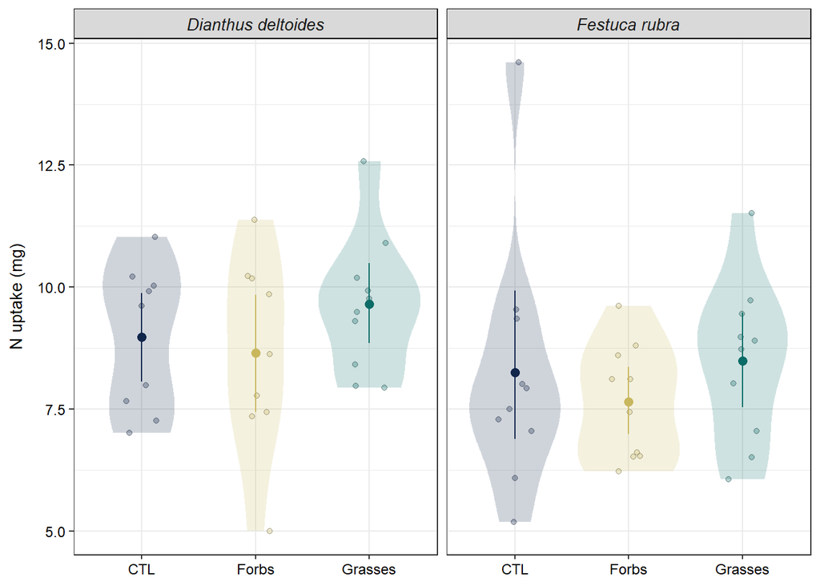

```r
cbPalette <- c("#C9B75E", "#0C6C67", "#11264B")

cex.axis<-9
cex.title<-10
cex.pt<-1.5

n<-ggplot(data, aes(x=Treatment, y=Nuptake, fill=Treatment))+
  facet_wrap(~Species)+
  stat_ydensity(color=adjustcolor("white", alpha.f = 0.1), alpha=0.2)+
  geom_jitter(aes(x=Treatment, y=Nuptake, fill=Treatment), shape=21, size=cex.pt, alpha=0.3,
              position=position_jitter(width=0.15))+
  stat_summary(aes(x=Treatment, y=Nuptake, color=Treatment),
               fun.data="mean_cl_boot", fun.args = list(B=10000), size=0.5, shape=16)+
  theme_bw()+
  xlab("")+
  ylab("N uptake (mg)")+
  theme(axis.title=element_text(size=cex.title, color="black", face="plain"),
        axis.title.y=element_text(margin = margin(t = 0, r = 8, b = 0, l = 0)),
        axis.title.x=element_blank(),
        axis.text=element_text(size=cex.axis, color="black"),
        legend.position = "none",
        strip.text = element_text(size=cex.title, face="italic"),
        strip.background=element_rect(color="black"))+
  scale_x_discrete(limits=c("Soil", "Forbs", "Grasses"),
                   labels=c("CTL", "Forbs", "Grasses"))+
  scale_fill_manual(values=cbPalette)+
  scale_color_manual(values=cbPalette)

n
```

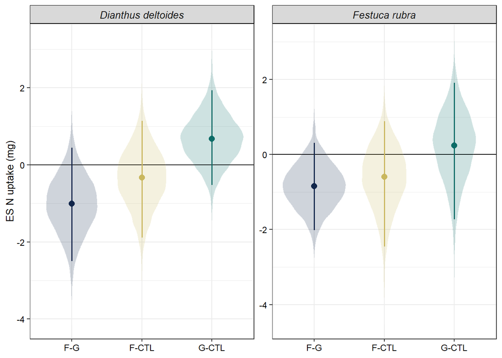

```r
es_Nuptake<-bootstrap_ES(response="Nuptake", data=data, n_perm=10000, plot=FALSE)

cex.axis<-9
cex.title<-10
cex.pt<-1.5
cex.mean<-2.5

cbPalette <- c("#11264B", "#C9B75E", "#0C6C67")

esn<-ggplot(data)+
  facet_wrap(~Species, scales="free_y")+
  geom_hline(yintercept=0)+
  stat_ydensity(data=es_Nuptake$bootstrap, aes(x=Contrast, y=ES, fill=Contrast), color=adjustcolor("white", alpha.f = 0.1), alpha=0.2, inherit.aes = FALSE)+
  geom_segment(data=es_Nuptake$summary, aes(x=Contrast, xend=Contrast, y=lowCI, yend=highCI, color=Contrast), size=0.6, inherit.aes = F)+
  geom_point(data=es_Nuptake$summary, mapping=aes(x=Contrast, y=ES, color=Contrast, fill=Contrast), shape=21, size=cex.mean, inherit.aes = F)+
  theme_bw()+
  xlab("")+
  ylab("ES N uptake (mg)")+
  theme(axis.title=element_text(size=cex.title, color="black", face="plain"),
        axis.title.y=element_text(margin = margin(t = 0, r = 2, b = 0, l = 0)),
        axis.title.x=element_blank(),
        axis.text=element_text(size=cex.axis, color="black"),
        legend.position = "none",
        strip.text = element_text(size=10, face="italic"),
        strip.background=element_rect(color="black"))+
  scale_fill_manual(values=cbPalette)+
  scale_color_manual(values=cbPalette)+
  scale_x_discrete(limits=c("Forbs-Grasses", "Forbs-Soil", "Grasses-Soil"),
                   labels=c("F-G", "F-CTL", "G-CTL"))

esn
```

# Structural equation modelling

## *Dianthus deltoides*

### CTL-Forbs

```r
data_forbs<-data[data$SampleID<=30 & data$Treatment!="Grasses",]
data_forbs$Forbs<-c(rep(1,9), rep(0,9))

model_forbs<-psem(lm(RDW~Forbs, data=data_forbs),
                  lm(SRL~D+Forbs, data=data_forbs),
                  lm(D~Forbs, data=data_forbs),
                  lm(SRA~SRL+D, data=data_forbs),
                  lm(Nuptake~RDW+SRA+Forbs, data=data_forbs))

summary(model_forbs, .progressBar = F)
```

```
##
## Structural Equation Model of model_forbs
##
## Call:
##   RDW ~ Forbs
##   SRL ~ D + Forbs
##   D ~ Forbs
##   SRA ~ SRL + D
##   Nuptake ~ RDW + SRA + Forbs
##
##     AIC      BIC
##  55.880   72.797
##
## ---
## Tests of directed separation:
##
##        Independ.Claim Test.Type DF Crit.Value P.Value
##     SRA ~ Forbs + ...      coef 14    -0.6723  0.5123
##         D ~ RDW + ...      coef 15     1.3901  0.1848
##       SRL ~ RDW + ...      coef 14    -1.2689  0.2252
##       SRA ~ RDW + ...      coef 13    -0.1435  0.8881
##     Nuptake ~ D + ...      coef 13    -0.8624  0.4041
##   Nuptake ~ SRL + ...      coef 12     2.7646  0.0171 *
##
## Global goodness-of-fit:
##
##   Fisher's C = 17.88 with P-value = 0.119 and on 12 degrees of freedom
##
## ---
## Coefficients:
##
##   Response Predictor   Estimate Std.Error DF Crit.Value P.Value Std.Estimate
##        RDW     Forbs    -0.0243    0.0071 16    -3.4396  0.0034      -0.6520  **
##        SRL         D -5229.4583 1549.4492 15    -3.3750  0.0042      -0.6197  **
##        SRL     Forbs   -49.5868   34.8429 15    -1.4232  0.1752      -0.2613
##          D     Forbs     0.0041    0.0055 16     0.7333  0.4740       0.1803
##        SRA       SRL     0.0005    0.0000 15    54.4042  0.0000       1.3068 ***
##        SRA         D     2.2889    0.0840 15    27.2643  0.0000       0.6549 ***
##    Nuptake       RDW    48.3826   29.9040 14     1.6179  0.1280       0.5449
##    Nuptake       SRA    -2.7865   11.6090 14    -0.2400  0.8138      -0.0663
##    Nuptake     Forbs     0.7645    1.2034 14     0.6353  0.5355       0.2314
##
##   Signif. codes:  0 '***' 0.001 '**' 0.01 '*' 0.05
##
## ---
## Individual R-squared:
##
##   Response method R.squared
##        RDW   none      0.43
##        SRL   none      0.51
##          D   none      0.03
##        SRA   none      1.00
##    Nuptake   none      0.20
```

```r
maxi<-max(summary(model_forbs, .progressBar = F)$coeff$Std.Estimate[which(summary(model_forbs, .progressBar = F)$coeff$P.Value<0.05)])

knitr::kable(
data.frame(Response=summary(model_forbs, .progressBar = F)$coeff$Response,
           Predictor=summary(model_forbs, .progressBar = F)$coeff$Predictor,
           Std.Estimate=round(summary(model_forbs, .progressBar = F)$coeff$Std.Estimate, 2),
           lwd=round(5*abs(summary(model_forbs, .progressBar = F)$coeff$Std.Estimate)/maxi, 1),
           Signif=summary(model_forbs, .progressBar = F)$coeff[,9]), caption="Results SEM Dianthus deltoides CTL-Forbs")
```

Results SEM Dianthus deltoides CTL-Forbs

| Response | Predictor | Std.Estimate | lwd | Signif |
| --- | --- | --- | --- | --- |
| RDW | Forbs | -0.65 | 2.5 | ** |
| SRL | D | -0.62 | 2.4 | ** |
| SRL | Forbs | -0.26 | 1.0 |  |
| D | Forbs | 0.18 | 0.7 |  |
| SRA | SRL | 1.31 | 5.0 | *** |
| SRA | D | 0.65 | 2.5 | *** |
| Nuptake | RDW | 0.54 | 2.1 |  |
| Nuptake | SRA | -0.07 | 0.3 |  |
| Nuptake | Forbs | 0.23 | 0.9 |  |

### CTL-Grasses

```r
data_grasses<-data[data$SampleID<=30 & data$Treatment!="Forbs",]
data_grasses$Grasses<-c(rep(1,10), rep(0,9))

model_grasses<-psem(lm(RDW~Grasses, data=data_grasses),
                    lm(SRL~D+Grasses, data=data_grasses),
                    lm(D~Grasses, data=data_grasses),
                    lm(SRA~SRL+D, data=data_grasses),
                    lm(Nuptake~RDW+SRA+Grasses, data=data_grasses))

summary(model_grasses, .progressBar = F)
```

```
##
## Structural Equation Model of model_grasses
##
## Call:
##   RDW ~ Grasses
##   SRL ~ D + Grasses
##   D ~ Grasses
##   SRA ~ SRL + D
##   Nuptake ~ RDW + SRA + Grasses
##
##     AIC      BIC
##  45.410   63.354
##
## ---
## Tests of directed separation:
##
##        Independ.Claim Test.Type DF Crit.Value P.Value
##   SRA ~ Grasses + ...      coef 15     1.0607  0.3056
##         D ~ RDW + ...      coef 16     0.8284  0.4196
##       SRL ~ RDW + ...      coef 15    -0.4767  0.6404
##       SRA ~ RDW + ...      coef 14     0.0608  0.9524
##     Nuptake ~ D + ...      coef 14    -0.7066  0.4914
##   Nuptake ~ SRL + ...      coef 13    -0.4791  0.6399
##
## Global goodness-of-fit:
##
##   Fisher's C = 7.41 with P-value = 0.829 and on 12 degrees of freedom
##
## ---
## Coefficients:
##
##   Response Predictor   Estimate Std.Error DF Crit.Value P.Value Std.Estimate
##        RDW   Grasses    -0.0041    0.0065 17    -0.6304  0.5368      -0.1511
##        SRL         D -4328.4885 1204.7567 16    -3.5928  0.0024      -0.5537  **
##        SRL   Grasses   -87.8501   24.3730 16    -3.6044  0.0024      -0.5555  **
##          D   Grasses     0.0002    0.0049 17     0.0329  0.9741       0.0080
##        SRA       SRL     0.0005    0.0000 16    72.5593  0.0000       1.2030 ***
##        SRA         D     2.2063    0.0565 16    39.0340  0.0000       0.6472 ***
##    Nuptake       RDW    -2.1681   26.4615 15    -0.0819  0.9358      -0.0209
##    Nuptake       SRA    -2.1048   13.7104 15    -0.1535  0.8800      -0.0514
##    Nuptake   Grasses     0.5722    0.9566 15     0.5982  0.5586       0.2027
##
##   Signif. codes:  0 '***' 0.001 '**' 0.01 '*' 0.05
##
## ---
## Individual R-squared:
##
##   Response method R.squared
##        RDW   none      0.02
##        SRL   none      0.62
##          D   none      0.00
##        SRA   none      1.00
##    Nuptake   none      0.06
```

```r
maxi<-max(summary(model_grasses, .progressBar = F)$coeff$Std.Estimate[which(summary(model_grasses, .progressBar = F)$coeff$P.Value<0.05)])

knitr::kable(
data.frame(Response=summary(model_grasses, .progressBar = F)$coeff$Response,
           Predictor=summary(model_grasses, .progressBar = F)$coeff$Predictor,
           Std.Estimate=round(summary(model_grasses, .progressBar = F)$coeff$Std.Estimate, 2),
           lwd=round(5*abs(summary(model_grasses, .progressBar = F)$coeff$Std.Estimate)/maxi, 1),
           Signif=summary(model_grasses, .progressBar = F)$coeff[,9]), caption="Results SEM Dianthus deltoides CTL-Grasses")
```

Results SEM Dianthus deltoides CTL-Grasses

| Response | Predictor | Std.Estimate | lwd | Signif |
| --- | --- | --- | --- | --- |
| RDW | Grasses | -0.15 | 0.6 |  |
| SRL | D | -0.55 | 2.3 | ** |
| SRL | Grasses | -0.56 | 2.3 | ** |
| D | Grasses | 0.01 | 0.0 |  |
| SRA | SRL | 1.20 | 5.0 | *** |
| SRA | D | 0.65 | 2.7 | *** |
| Nuptake | RDW | -0.02 | 0.1 |  |
| Nuptake | SRA | -0.05 | 0.2 |  |
| Nuptake | Grasses | 0.20 | 0.8 |  |

## *Festuca rubra*

### CTL-Forbs

```r
data_forbs<-data[data$SampleID>30 & data$Treatment!="Grasses",]
data_forbs$Forbs<-c(rep(1,10), rep(0,10))

model_forbs<-psem(lm(RDW~Forbs, data=data_forbs),
                  lm(SRL~D+Forbs, data=data_forbs),
                  lm(D~Forbs, data=data_forbs),
                  lm(SRA~SRL+D, data=data_forbs),
                  lm(Nuptake~RDW+SRA+Forbs, data=data_forbs))

summary(model_forbs, .progressBar = F)
```

```
##
## Structural Equation Model of model_forbs
##
## Call:
##   RDW ~ Forbs
##   SRL ~ D + Forbs
##   D ~ Forbs
##   SRA ~ SRL + D
##   Nuptake ~ RDW + SRA + Forbs
##
##     AIC      BIC
##  48.563   67.482
##
## ---
## Tests of directed separation:
##
##        Independ.Claim Test.Type DF Crit.Value P.Value
##     SRA ~ Forbs + ...      coef 16    -0.1403  0.8902
##         D ~ RDW + ...      coef 17    -0.3337  0.7427
##       SRL ~ RDW + ...      coef 16     0.3101  0.7605
##       SRA ~ RDW + ...      coef 15    -1.2964  0.2144
##     Nuptake ~ D + ...      coef 15     1.8253  0.0879
##   Nuptake ~ SRL + ...      coef 14    -0.6337  0.5365
##
## Global goodness-of-fit:
##
##   Fisher's C = 10.563 with P-value = 0.567 and on 12 degrees of freedom
##
## ---
## Coefficients:
##
##   Response Predictor   Estimate Std.Error DF Crit.Value P.Value Std.Estimate
##        RDW     Forbs    -0.0052    0.0166 18    -0.3156  0.7560      -0.0742
##        SRL         D -8560.0459 2171.2924 17    -3.9424  0.0011      -0.6950  **
##        SRL     Forbs    -8.5207   51.9384 17    -0.1641  0.8716      -0.0289
##          D     Forbs     0.0047    0.0055 18     0.8431  0.4102       0.1949
##        SRA       SRL     0.0004    0.0000 17    35.0869  0.0000       1.2882 ***
##        SRA         D     2.0606    0.1445 17    14.2642  0.0000       0.5237 ***
##    Nuptake       RDW    18.4403   12.4411 16     1.4822  0.1577       0.3379
##    Nuptake       SRA     7.3032    9.3768 16     0.7789  0.4474       0.1782
##    Nuptake     Forbs    -0.4242    0.8825 16    -0.4807  0.6372      -0.1100
##
##   Signif. codes:  0 '***' 0.001 '**' 0.01 '*' 0.05
##
## ---
## Individual R-squared:
##
##   Response method R.squared
##        RDW   none      0.01
##        SRL   none      0.49
##          D   none      0.04
##        SRA   none      0.99
##    Nuptake   none      0.18
```

```r
maxi<-max(summary(model_forbs, .progressBar = F)$coeff$Std.Estimate[which(summary(model_forbs, .progressBar = F)$coeff$P.Value<0.05)])

knitr::kable(
data.frame(Response=summary(model_forbs, .progressBar = F)$coeff$Response,
           Predictor=summary(model_forbs, .progressBar = F)$coeff$Predictor,
           Std.Estimate=round(summary(model_forbs, .progressBar = F)$coeff$Std.Estimate, 2),
           lwd=round(5*abs(summary(model_forbs, .progressBar = F)$coeff$Std.Estimate)/maxi, 1),
           Signif=summary(model_forbs, .progressBar = F)$coeff[,9]), caption="Results SEM Festuca rubra CTL-Forbs")
```

Results SEM Festuca rubra CTL-Forbs

| Response | Predictor | Std.Estimate | lwd | Signif |
| --- | --- | --- | --- | --- |
| RDW | Forbs | -0.07 | 0.3 |  |
| SRL | D | -0.70 | 2.7 | ** |
| SRL | Forbs | -0.03 | 0.1 |  |
| D | Forbs | 0.19 | 0.8 |  |
| SRA | SRL | 1.29 | 5.0 | *** |
| SRA | D | 0.52 | 2.0 | *** |
| Nuptake | RDW | 0.34 | 1.3 |  |
| Nuptake | SRA | 0.18 | 0.7 |  |
| Nuptake | Forbs | -0.11 | 0.4 |  |

### CTL-Grasses

```r
data_grasses<-data[data$SampleID>30 & data$Treatment!="Forbs",]
data_grasses$Grasses<-c(rep(1,10), rep(0,10))

model_grasses<-psem(lm(RDW~Grasses, data=data_grasses),
                    lm(SRL~D+Grasses, data=data_grasses),
                    lm(D~Grasses, data=data_grasses),
                    lm(SRA~SRL+D, data=data_grasses),
                    lm(Nuptake~RDW+SRA+Grasses, data=data_grasses))

summary(model_grasses, .progressBar = F)
```

```
##
## Structural Equation Model of model_grasses
##
## Call:
##   RDW ~ Grasses
##   SRL ~ D + Grasses
##   D ~ Grasses
##   SRA ~ SRL + D
##   Nuptake ~ RDW + SRA + Grasses
##
##     AIC      BIC
##  55.672   74.591
##
## ---
## Tests of directed separation:
##
##        Independ.Claim Test.Type DF Crit.Value P.Value
##   SRA ~ Grasses + ...      coef 16    -0.0220  0.9827
##         D ~ RDW + ...      coef 17     1.4270  0.1717
##       SRL ~ RDW + ...      coef 16    -1.8798  0.0785
##       SRA ~ RDW + ...      coef 15     0.5200  0.6106
##     Nuptake ~ D + ...      coef 15     2.6307  0.0189 *
##   Nuptake ~ SRL + ...      coef 14     0.0619  0.9515
##
## Global goodness-of-fit:
##
##   Fisher's C = 17.672 with P-value = 0.126 and on 12 degrees of freedom
##
## ---
## Coefficients:
##
##   Response Predictor    Estimate Std.Error DF Crit.Value P.Value Std.Estimate
##        RDW   Grasses      0.0038    0.0189 18     0.1997  0.8440       0.0470
##        SRL         D -10116.1682 2422.4482 17    -4.1760  0.0006      -0.7198
##        SRL   Grasses     -1.4006   45.0933 17    -0.0311  0.9756      -0.0054
##          D   Grasses     -0.0039    0.0043 18    -0.8998  0.3801      -0.2075
##        SRA       SRL      0.0004    0.0000 17    31.1384  0.0000       1.3094
##        SRA         D      2.4668    0.1902 17    12.9684  0.0000       0.5453
##    Nuptake       RDW     22.7491   13.2601 16     1.7156  0.1055       0.4430
##    Nuptake       SRA     18.5830   12.6597 16     1.4679  0.1615       0.3797
```

[output cut: 8 more lines]

```
##
##
##
##
##   Signif. codes:  0 '***' 0.001 '**' 0.01 '*' 0.05
##
## ---
## Individual R-squared:
##
##   Response method R.squared
##        RDW   none      0.00
##        SRL   none      0.52
##          D   none      0.04
##        SRA   none      0.99
##    Nuptake   none      0.18
```

```r
maxi<-max(summary(model_grasses, .progressBar = F)$coeff$Std.Estimate[which(summary(model_grasses, .progressBar = F)$coeff$P.Value<0.05)])

knitr::kable(
data.frame(Response=summary(model_grasses, .progressBar = F)$coeff$Response,
           Predictor=summary(model_grasses, .progressBar = F)$coeff$Predictor,
           Std.Estimate=round(summary(model_grasses, .progressBar = F)$coeff$Std.Estimate, 2),
           lwd=round(5*abs(summary(model_grasses, .progressBar = F)$coeff$Std.Estimate)/maxi, 1),
           Signif=summary(model_grasses, .progressBar = F)$coeff[,9]), caption="Results SEM Festuca rubra CTL-Grasses")
```

Results SEM Festuca rubra CTL-Grasses

| Response | Predictor | Std.Estimate | lwd | Signif |
| --- | --- | --- | --- | --- |
| RDW | Grasses | 0.05 | 0.2 |  |
| SRL | D | -0.72 | 2.7 | *** |
| SRL | Grasses | -0.01 | 0.0 |  |
| D | Grasses | -0.21 | 0.8 |  |
| SRA | SRL | 1.31 | 5.0 | *** |
| SRA | D | 0.55 | 2.1 | *** |
| Nuptake | RDW | 0.44 | 1.7 |  |
| Nuptake | SRA | 0.38 | 1.4 |  |
| Nuptake | Grasses | 0.01 | 0.0 |  |